# Linear Regression

More articles in my blog: $\hspace{0.1cm}$ [Estadistica4all](https://fabioscielzoortiz.github.io/Estadistica4all.github.io/)

How to reference this article ?

Scielzo Ortiz, F. (2022). Linear Regression with Python and R. *Estadistica4all*. [Linear Regression with Python and R](https://fabioscielzoortiz.github.io/Estadistica4all.github.io/Articulos/Linear%20Regression%20in%20Python%20and%20R.html)

# 1 Data-set description

We are going to describe the data-set we will use in this article.

The data are 1905 observation about 38 variables on housing features.

Here is the link where the data was loaded: https://www.kaggle.com/datasets/dataregress/dubai-properties-dataset?resource=download

The variables of our interest are the following:

- id : identificator
- neighborhood: the name of the neighborhood
- latitude: the latitude of the house
- longitude: the longitude of the house
- price: the market price of the house
- size_in_sqft: the size of the house in square foot
  - 1 sqft = 0.092903 $m^2$
- price_per_sqft: the market price of the house per square foot
- no_of_bedrooms: number of bedrooms in the house
- no_of_bathrooms: number of bathrooms in the house
- quality: quality of the house. Based on the number of services. Her categories are Ultra, High, Medium and Low
- maid_room: indicates if the house has maid room (cuarto de servicio) (true/false)
- unfurnished: indicates if the house is unfurnished (sin amueblar) (true/false)
- balcony: indicates if the house has balcony (true/false)
- barbecue_area: indicates if the house has barbecue area (true/false)
- central_ac: indicates if the house has central air conditioning (true/false)
- childrens_play_area: indicatees if the house has childrens game area (true/false)
- childrens_pool: indicates if the house has childrens pool (true/false)
- concierge: indicates if the house has concierge (true/false)
- covered_parking: indicates if the house has covered parking (true/false)
- kitchen_appliances: indicates if the house has kitchen appliances (electrodomesticos de cocina) (true/false)
- maid_service: indicates if the house has maid service (servicio de limpieza) (true/false)
- pets_allowed: indicates if pets are allowed(true/false)
- private_garden: indicates if the house has private garden (true/false)
- private_gym: indicates if the house has private gym (true/false)
- private_jacuzzi: indicates if the house has private jacuzzi (true/false)
- private_pool: indicates if the house has private pool (true/false)
- security: indicates if the house has private secutity (true/false)
- shared_gym: indicates if the house has shared gym (true/false)
- shared_pool: indicates if the house has shared pool (true/false)
- shared_spa: indicates if the house has shared spa (true/false)
- view_of_water: indicates if the house has view of the water (true/false)

Now we are going to do the following:

1. We are going to load an manipulate the data-set in R
2. We will repeat this task in Python

## 1.1 Data Manipulation in `R`

```python
import rpy2

%load_ext rpy2.ipython

import rpy2.robjects as robjects
```

We load the data-set with which we are going to work:

```r
%%R

library(tidyverse)

url = 'https://raw.githubusercontent.com/FabioScielzoOrtiz/Estadistica4all-blog/main/Linear%20Regression%20in%20Python%20and%20R/properties_data.csv'

properties_data <- read_csv(url)
```

Now, we are going to tranformate the variables that are measured in square foot (sqft) to square meters $(m^2)$

size_in_m_2 = 0.092903 * size_in_sqft

price_per_m_2 = price_per_sqft / 0.092903

Now, we are going to tranformate the variables that are measured in square foot (sqft) to square meters $(m^2)$

size_in_m_2 = 0.092903 * size_in_sqft

price_per_m_2 = price_per_sqft / 0.092903

```r
%%R

size_in_m_2 <-  0.092903*properties_data$size_in_sqft

properties_data$size_in_m_2 <- size_in_m_2

price_per_m_2 <- properties_data$price_per_sqft /  0.092903

properties_data$price_per_m_2 <- price_per_m_2
```

The following step will be convert the categorical variables to factor in R and remove in the data-set the variables that we will not take into account:

```r
%%R
levels(properties_data$quality)
```

```r
%%R

properties_data$quality = recode_factor(properties_data$quality , "Low" = 0 , "Medium" = 1 , "High" = 2  , "Ultra" = 3)
```

```r
%%R

properties_data$quality = factor(properties_data$quality)
```

```r
%%R

data_R <- properties_data %>% select("price", "size_in_m_2", "longitude", "latitude", "no_of_bedrooms", "no_of_bathrooms", "quality")

head(data_R,15)
```

```
# A tibble: 15 x 7
     price size_in_m_2 longitude latitude no_of_bedrooms no_of_bathrooms quality
     <dbl>       <dbl>     <dbl>    <dbl>          <dbl>           <dbl> <fct>
 1 2700000       100.       55.1     25.1              1               2 1
 2 2850000       147.       55.2     25.1              2               2 1
 3 1150000       181.       55.1     25.1              3               5 1
 4 2850000       188.       55.3     25.2              2               3 0
 5 1729200        47.1      55.1     25.1              0               1 1
 6 3119900        94.3      55.1     25.1              1               2 1
 7 8503600       192.       55.1     25.1              2               3 2
 8 3119900        94.3      55.1     25.1              1               2 1
 9 2100000       203.       55.1     25.1              3               3 0
10 2690000       141.       55.3     25.2              2               3 1
11 3550000       178.       55.3     25.2              3               4 0
12 2094999        98.3      55.1     25.1              2               3 0
13 1049999        56.6      55.1     25.1              1               2 0
14 1849000        99.5      55.2     25.1              1               1 1
15 2089999        97.6      55.2     25.1              1               1 1
```

## 1.2 Data Manipulation in `Python`

```python
import pandas as pd

from dfply import *

import warnings
warnings.filterwarnings('ignore')
```

```python
url = 'https://raw.githubusercontent.com/FabioScielzoOrtiz/Estadistica4all-blog/main/Linear%20Regression%20in%20Python%20and%20R/properties_data.csv'

data_Python = pd.read_csv(url)

data_Python
```

|  | id | neighborhood | latitude | longitude | price | size_in_sqft | price_per_sqft | no_of_bedrooms | no_of_bathrooms | quality | … | private_pool | security | shared_gym | shared_pool | shared_spa | study | vastu_compliant | view_of_landmark | view_of_water | walk_in_closet |
| --- | --- | --- | --- | --- | --- | --- | --- | --- | --- | --- | --- | --- | --- | --- | --- | --- | --- | --- | --- | --- | --- |
| 0 | 5528049 | Palm Jumeirah | 25.113208 | 55.138932 | 2700000 | 1079 | 2502.32 | 1 | 2 | Medium | … | False | False | True | False | False | False | False | False | True | False |
| 1 | 6008529 | Palm Jumeirah | 25.106809 | 55.151201 | 2850000 | 1582 | 1801.52 | 2 | 2 | Medium | … | False | False | True | True | False | False | False | False | True | False |
| 2 | 6034542 | Jumeirah Lake Towers | 25.063302 | 55.137728 | 1150000 | 1951 | 589.44 | 3 | 5 | Medium | … | False | True | True | True | False | False | False | True | True | True |
| 3 | 6326063 | Culture Village | 25.227295 | 55.341761 | 2850000 | 2020 | 1410.89 | 2 | 3 | Low | … | False | False | False | False | False | False | False | False | False | False |
| 4 | 6356778 | Palm Jumeirah | 25.114275 | 55.139764 | 1729200 | 507 | 3410.65 | 0 | 1 | Medium | … | False | True | True | True | True | False | False | True | True | False |
| … | … | … | … | … | … | … | … | … | … | … | … | … | … | … | … | … | … | … | … | … | … |
| 1900 | 7705450 | Mohammed Bin Rashid City | 25.176892 | 55.310712 | 1500000 | 1087 | 1379.94 | 2 | 2 | Ultra | … | False | True | True | True | True | True | True | True | True | True |
| 1901 | 7706287 | Mohammed Bin Rashid City | 25.166145 | 55.276684 | 1230000 | 760 | 1618.42 | 1 | 2 | Medium | … | False | False | True | True | False | False | False | False | True | True |
| 1902 | 7706389 | Dubai Creek Harbour (The Lagoons) | 25.206500 | 55.345056 | 2900000 | 1930 | 1502.59 | 3 | 5 | Medium | … | False | False | False | True | False | False | False | False | False | False |
| 1903 | 7706591 | Jumeirah Village Circle | 25.073858 | 55.229844 | 675000 | 740 | 912.16 | 1 | 2 | Medium | … | False | True | True | True | False | False | False | False | True | True |
| 1904 | 7706643 | Jumeirah Lake Towers | 25.079130 | 55.154713 | 760887 | 800 | 951.11 | 1 | 2 | High | … | False | True | True | True | True | False | False | False | True | False |

1905 rows × 38 columns

```python
data_Python['size_in_m_2'] = 0.092903*data_Python['size_in_sqft']
data_Python['price_per_m_2'] = data_Python['price_per_sqft']/0.092903
```

```python
data_Python = data_Python >> select(X.price , X.size_in_m_2, X.longitude, X.latitude, X.no_of_bedrooms, X.no_of_bathrooms, X.quality)
data_Python
```

|  | price | size_in_m_2 | longitude | latitude | no_of_bedrooms | no_of_bathrooms | quality |
| --- | --- | --- | --- | --- | --- | --- | --- |
| 0 | 2700000 | 100.242337 | 55.138932 | 25.113208 | 1 | 2 | Medium |
| 1 | 2850000 | 146.972546 | 55.151201 | 25.106809 | 2 | 2 | Medium |
| 2 | 1150000 | 181.253753 | 55.137728 | 25.063302 | 3 | 5 | Medium |
| 3 | 2850000 | 187.664060 | 55.341761 | 25.227295 | 2 | 3 | Low |
| 4 | 1729200 | 47.101821 | 55.139764 | 25.114275 | 0 | 1 | Medium |
| … | … | … | … | … | … | … | … |
| 1900 | 1500000 | 100.985561 | 55.310712 | 25.176892 | 2 | 2 | Ultra |
| 1901 | 1230000 | 70.606280 | 55.276684 | 25.166145 | 1 | 2 | Medium |
| 1902 | 2900000 | 179.302790 | 55.345056 | 25.206500 | 3 | 5 | Medium |
| 1903 | 675000 | 68.748220 | 55.229844 | 25.073858 | 1 | 2 | Medium |
| 1904 | 760887 | 74.322400 | 55.154713 | 25.079130 | 1 | 2 | High |

1905 rows × 7 columns

Converting $quality$ to categorical:

```python
data_Python.dtypes
```

```
price                int64
size_in_m_2        float64
longitude          float64
latitude           float64
no_of_bedrooms       int64
no_of_bathrooms      int64
quality             object
dtype: object
```

Recoding the categorical variable $quality$

```python
data_Python['quality'].unique()
```

```
array(['Medium', 'Low', 'High', 'Ultra'], dtype=object)
```

```python
(data_Python['quality_recode']) = 0

for i in range(0 , len(data_Python)) :

    if (data_Python['quality'])[i] == 'Low' :

        (data_Python['quality_recode'])[i] = 0

    if (data_Python['quality'])[i] == 'Medium' :

        (data_Python['quality_recode'])[i] = 1

    if (data_Python['quality'])[i] == 'High' :

        (data_Python['quality_recode'])[i] = 2

    if (data_Python['quality'])[i] == 'Ultra' :

        (data_Python['quality_recode'])[i] = 3
```

```python
data_Python.head()
```

|  | price | size_in_m_2 | longitude | latitude | no_of_bedrooms | no_of_bathrooms | quality | quality_recode |
| --- | --- | --- | --- | --- | --- | --- | --- | --- |
| 0 | 2700000 | 100.242337 | 55.138932 | 25.113208 | 1 | 2 | Medium | 1 |
| 1 | 2850000 | 146.972546 | 55.151201 | 25.106809 | 2 | 2 | Medium | 1 |
| 2 | 1150000 | 181.253753 | 55.137728 | 25.063302 | 3 | 5 | Medium | 1 |
| 3 | 2850000 | 187.664060 | 55.341761 | 25.227295 | 2 | 3 | Low | 0 |
| 4 | 1729200 | 47.101821 | 55.139764 | 25.114275 | 0 | 1 | Medium | 1 |

```python
data_Python = data_Python >> select( ~X.quality )
```

```python
data_Python = data_Python >> rename(quality = X.quality_recode)
```

```python
data_Python['quality'] = data_Python['quality'].astype('category')
```

```python
data_Python.dtypes
```

```
price                 int64
size_in_m_2         float64
longitude           float64
latitude            float64
no_of_bedrooms        int64
no_of_bathrooms       int64
quality            category
dtype: object
```

The final data-set in Python would be:

```python
data_Python
```

|  | price | size_in_m_2 | longitude | latitude | no_of_bedrooms | no_of_bathrooms | quality |
| --- | --- | --- | --- | --- | --- | --- | --- |
| 0 | 2700000 | 100.242337 | 55.138932 | 25.113208 | 1 | 2 | 1 |
| 1 | 2850000 | 146.972546 | 55.151201 | 25.106809 | 2 | 2 | 1 |
| 2 | 1150000 | 181.253753 | 55.137728 | 25.063302 | 3 | 5 | 1 |
| 3 | 2850000 | 187.664060 | 55.341761 | 25.227295 | 2 | 3 | 0 |
| 4 | 1729200 | 47.101821 | 55.139764 | 25.114275 | 0 | 1 | 1 |
| … | … | … | … | … | … | … | … |
| 1900 | 1500000 | 100.985561 | 55.310712 | 25.176892 | 2 | 2 | 3 |
| 1901 | 1230000 | 70.606280 | 55.276684 | 25.166145 | 1 | 2 | 1 |
| 1902 | 2900000 | 179.302790 | 55.345056 | 25.206500 | 3 | 5 | 1 |
| 1903 | 675000 | 68.748220 | 55.229844 | 25.073858 | 1 | 2 | 1 |
| 1904 | 760887 | 74.322400 | 55.154713 | 25.079130 | 1 | 2 | 2 |

1905 rows × 7 columns

We can write the last data-frame as csv as follows:

```python
data_Python.to_csv('data_Python.csv' , index=False)
```

**Important**: to use categorical variables in a linear regression model in Python they must be recoded (their values must be numbers that represents their categories), i.e, we cannot use the variable *quality* , instead of it we can use *quality_recode*

This is the reason we have recoded *quality* in Python but not in R, because in R is not strictly necessary.

Note we have obtained the same data-set that was obtained with R.

- The R data-set has been called *data_R*
- The Python data-set has been called *data_python*

We will use both of them throughout this article.

# 2 Introduction to the Linear Regression Model

The principal propose of this article is carry out a theoretical and also practical exposition of the linear regression model.

Without any doubt this is the most know statistical model.

There is the idea that linear regression model is outdated compared with other modern statistical models. But I would like to defend his validity nowadays, first of all as a statistical tool, and second as a previous necessary step to learn other most modern and complex methods.

The linear regression model is the base of many modern regression techniques, so that is highly recommended study it enough, before to go deeper in other statistical models.

## 2.1 Usefulness of the Linear Regression Model

The main usefulness of the linear regression model is to **predict** the values of a **quantitative** variable, called **response variable**, depending on the values of other, **quantitative** or **categorical** variables , called **predictors**.

The other important usefulness of the linear regression model is to do **inference**, in other words, analyze the relation between the response variable and the predictors.

Some questions related to making inferences are as follows:

- Which predictors are most important in explaining the response?
- What is the relationship between the response and each predictor? Is the relationship positive, negative, or does it depend on the value of another predictor?
- Can the relationship between response and predictors be summarized with a linear equation, or is it a more complex relationship?

## 2.2 Formal Approach to the Linear Regression Model

We have the following elements:

- *Response Variable:*

$\hspace{1.5cm}$ A **quantitative** variable:

$$Y=(y_{1} , y_2,...,y_n)^t$$

- *Predictors:*

$\hspace{1.5cm}$ A set of **quantitative** or **categorical** variables:

$$\begin{gather*}
X_1 = (x_{11}, x_{21}, ..., x_{n1})^t \\
X_2 = (x_{12}, x_{22}, ..., x_{n2})^t \\
... \\
X_p = (x_{1p}, x_{2p}, ..., x_{np})^t
\end{gather*}$$

- *Predictors Matrix:*

  $$\begin{gather*}
  X=(1, X_1, X_2,...,X_p) =
  \begin{pmatrix}
  1 & x_{11}&x_{12}&...&x_{1p}\\
  1 & x_{21}&x_{22}&...&x_{2p}\\
  &...&\\
  1& x_{n1}&x_{n2}&...&x_{np}
  \end{pmatrix} =
  \begin{pmatrix}
  x_{1}\\
  x_{2}\\
  ...\\
  x_{n}
  \end{pmatrix}
  \end{gather*}$$
- *Beta Coefficients vector:*

$$\begin{gather*}
\beta=(\beta_{1}, \beta_{2}, ..., \beta_{n})^t
\end{gather*}$$

- *Errors (residuals) vector:*

$$\begin{gather*}
\varepsilon=(\varepsilon_{1}, \varepsilon_{2}, ..., \varepsilon_{n})^t
\end{gather*}$$

## 2.3 Basic Assumptions

The basic assumptions of the model are the following:

- $\hspace{0.3cm} y_i \hspace{0.1cm} = \hspace{0.1cm} x_i^t \cdot \beta + \varepsilon_i \hspace{0.1cm} = \hspace{0.1cm} \beta_0 + \sum_{j=1}^{p} \left( \beta_j \cdot x_{ij} \right) + \varepsilon_i \hspace{0.1cm} = \hspace{0.1cm} \beta_0 + \beta_1 \cdot x_{i1} + \beta_2 \cdot x_{i2} + \dots + \beta_p \cdot x_{ip} + \varepsilon_i$
- $\hspace{0.3cm} \varepsilon_i$ is a random variable such that:
  - $\hspace{0.3cm} E[\varepsilon_i]=0 \\$
  - $\hspace{0.3cm} Var(\varepsilon_i)=\sigma^2 \\$
  - $\hspace{0.3cm} \varepsilon_i \sim N(0,\sigma^2) \\$
  - $\hspace{0.3cm} cov(\varepsilon_i , \varepsilon_j)=0 \hspace{0.35cm} ,\forall i\neq j$
- $\hspace{0.3cm}$ Additional assumptions:
  - $\hspace{0.3cm} n > p+1 \\$
  - $\hspace{0.3cm} Rg(X)=p+1$

Why are these additional assumptions important ? $\hspace{0.1cm} \Rightarrow\hspace{0.1cm}$ **Dimensionality problem** (will be seen it in other article of the blog)

## 2.4 Assumptions Consequences

- $\hspace{0.15cm} y_i$ is a random variable because $\varepsilon_i$ is a random variable, and has the following propierties:
  - $\hspace{0.15cm} E[y_i]= x_i^t \cdot \beta \\$
  - $\hspace{0.15cm} Var(y_i) = \sigma^2 \\$
  - $\hspace{0.15cm} y_i \sim N(\hspace{0.1cm} x_i^t \cdot \beta \hspace{0.1cm} , \hspace{0.1cm} \sigma^2 \hspace{0.1cm} ) \\$
  - $\hspace{0.15cm} cov(y_i , y_j)=0 \hspace{0.25cm}, \forall i\neq j$

## 2.5 Matrix representation of the model

$$Y=X\cdot \beta + \varepsilon \\$$

Where:

- $\hspace{0.2cm} \varepsilon_i \sim N(0,\sigma) \hspace{0.4cm} \forall \hspace{0.1cm} i=1,...,n \\$
- $\hspace{0.2cm} cov(\varepsilon_i , \varepsilon_j)=0 \hspace{0.4cm} \forall \hspace{0.1cm} i\neq j =1,...,n$

# 3 Estimation

## 3.1 Prediction of Response Variable

The linear regression model predict the response variable value $\hspace{0.1cm}y_i\hspace{0.1cm}$ for the combination of predictors values $\hspace{0.1cm} x_i = (1,x_{i1}, x_{i2}, ..., x_{ip})^t \hspace{0.1cm}$ as:

$$\begin{gather*}
\widehat{y}_i \hspace{0.1cm}=\hspace{0.1cm} x_i^t \cdot \widehat{\beta} \hspace{0.1cm}=\hspace{0.1cm} \widehat{\beta}_0 + \sum_{j=1}^{p} \widehat{\beta}_j \cdot x_{ij} \hspace{0.1cm}=\hspace{0.1cm} \widehat{\beta}_0 + \widehat{\beta}_1 \cdot x_{i1} + \widehat{\beta}_2 \cdot x_{i2} + ... + \widehat{\beta}_p \cdot x_{ip}
\end{gather*}$$

Where:

- $\hspace{0.2cm}\widehat{\beta} = (\widehat{\beta}_1 ,..., \widehat{\beta}_p) \hspace{0.2cm}$ is the estimated beta coefficients vector.

## 3.2 Estimation of model coefficients

The estimation of $\hspace{0.1cm} \beta \hspace{0.1cm}$ in the classic linear regression model is done using ordinary least square method (OLS).

$\widehat{\beta} \hspace{0.1cm}$ is compute as the solution of the following optimitation problem:

$$\begin{gather*}
\underset{\beta}{Min} \hspace{0.2cm} \lbrace \hspace{0.15cm} RSS(\beta) \hspace{0.15cm} \rbrace \hspace{0.2cm} = \hspace{0.2cm} \underset{\beta}{Min} \hspace{0.2cm} \sum_{i=1}^{n} \hspace{0.1cm}(y_i - x_i^t \cdot \beta)\hspace{0.02cm}^2 \hspace{0.2cm} = \hspace{0.2cm} \underset{\beta_0,\beta_1,...,\beta_p}{Min} \hspace{0.2cm} \sum_{i=1}^{n} \hspace{0.1cm}(y_i - \beta_0 - \beta_1 \cdot x_{i1} - \dots - \beta_p \cdot x_{ip})\hspace{0.02cm}^2
\end{gather*}$$

So, other symbolic way to express that is:

$$\widehat{\beta}\hspace{0.15cm} =\hspace{0.15cm} arg \hspace{0.15cm} \underset{\beta}{Min} \hspace{0.15cm} \lbrace \hspace{0.15cm} RSS(\beta) \hspace{0.15cm} \rbrace$$

The **problem solution** is:

$$\begin{gather*}
\widehat{\beta}=(X^t \cdot X)^{-1} \cdot X^t \cdot Y
\end{gather*}$$

**Interpretation :**

$\hspace{0.2cm} \widehat{y} = x^t \cdot \widehat{\beta} \hspace{0.2cm}$ with $\hspace{0.2cm} x\in \mathbb{R}^p \hspace{0.2cm}$ is the hyperplane (with $\hspace{0.1cm}p+1\hspace{0.1cm}$ dimension) that **minimize** the **euclidean distance** between the given values of the response variable $(Y)$ and the points of the hyperplane given by the set $\hspace{0.1cm} \lbrace \hspace{0.2cm} \hat{y}_i = x_i^t \cdot \widehat{\beta} \hspace{0.2cm}/\hspace{0.2cm} i=1,...,n \hspace{0.2cm} \rbrace$

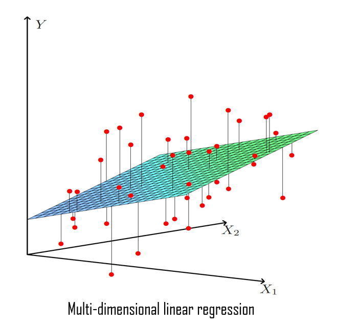

**Observation:**

We will not view here the mathematical details about the resolution of this optimization problem. But is a classic convex optimization problem, so it´s enough to take first derivatives of the objetive function with respect to the coefficients $\hspace{0.1cm}\beta_0,\beta_1,...,\beta_p \hspace{0.1cm}$ , set them equal to zero (0), and solve the resultant equation system with respect to $\hspace{0.1cm}\beta_0,\beta_1,...,\beta_p \hspace{0.1cm}$

## 3.3 Estimation of model errors (residuals)

The model errors $\varepsilon$ are estimated as:

$$\widehat{\varepsilon}_i \hspace{0.1 cm} = \hspace{0.1 cm} y_i - \widehat{y}_i \hspace{0.1 cm} = \hspace{0.1 cm} y_i - x_i^t \cdot \widehat{\beta}$$

for $\hspace{0.1cm}$ $i=1,...,n$

**Observation:**

$\hat{\varepsilon}_i$ is the error done by the model when it predicts $y_i$ as $\widehat{y}_i=x_i^t \cdot \widehat{\beta}$

## 3.4 Residual sum of squares (RSS)

The size of the errors is quantify as the estimated errors sum of squares :

$$RSS \hspace{0.1 cm} = \hspace{0.1 cm} \sum_{i=1}^{n} \hat{\varepsilon}_i\hspace{0.02cm}^2 \hspace{0.1 cm} = \hspace{0.1 cm} \sum_{i=1}^{n} (y_i - \widehat{y}_i)\hspace{0.02cm}^2 \hspace{0.1 cm} = \hspace{0.1 cm} \sum_{i=1}^{n} (y_i - x_i^t \cdot \widehat{\beta})\hspace{0.02cm}^2$$

**Observation:**

This quantity plays a central role in regression methods. As it was seen is the objective function in the OLS problem.

## 3.5 Regression Hyperplane

The regression hyperplane is the matrix expression of the predictions that the model does of the response variable values:

$$\widehat{Y} = X \cdot \widehat{\beta}$$

Where: $\hspace{0.2cm} \widehat{Y}=(\widehat{y}_1,\widehat{y}_2,...,\widehat{y}_n)^t$

## 3.6 Hat-Matrix

$$\begin{gather*}
\widehat{Y} = X \cdot \widehat{\beta} = X \cdot (X^t \cdot X)^{-1} \cdot X^t \cdot Y = H \cdot Y
\end{gather*}$$

Where:

$$H= X \cdot (X^t \cdot X)^{-1} \cdot X^t$$

is called **Hat-Matrix**

## 3.7 Estimation of the Linear Regression Model in `R`

In this section we are going to show how estimate a linear regression model in R, using for this purpose the data-set that was showed at the begining of the article.

The linear regression model that we propose is the following:

$$\begin{gather*}
price_i = \beta_0 + \beta_1 \cdot size\_in\_m\_2_i + \beta_2 \cdot no\_of\_bedrooms_i + \beta_3 \cdot no\_of\_bathrooms_i + \beta_4 \cdot quality_i + \beta_5\cdot latitude_i + \beta_6 \cdot longitude_i + \varepsilon_i
\end{gather*}$$

```r
%%R

model_R <- lm( price ~ size_in_m_2 + no_of_bedrooms + no_of_bathrooms + quality + latitude + longitude ,
data = data_R)

summary(model_R)
```

```
Call:
lm(formula = price ~ size_in_m_2 + no_of_bedrooms + no_of_bathrooms +
    quality + latitude + longitude, data = data_R)

Residuals:
      Min        1Q    Median        3Q       Max
-13398393   -562302     68143    562733  15384235

Coefficients:
                  Estimate Std. Error t value Pr(>|t|)
(Intercept)     -6.207e+07  2.995e+07  -2.073   0.0383 *
size_in_m_2      3.566e+04  7.238e+02  49.271  < 2e-16 ***
no_of_bedrooms  -8.367e+05  8.282e+04 -10.102  < 2e-16 ***
no_of_bathrooms -5.712e+04  6.829e+04  -0.836   0.4030
quality1         1.400e+05  8.358e+04   1.675   0.0940 .
quality2         3.406e+05  1.551e+05   2.196   0.0282 *
quality3         2.788e+05  1.976e+05   1.410   0.1586
latitude         6.115e+06  7.809e+05   7.830 8.03e-15 ***
longitude       -1.677e+06  6.908e+05  -2.428   0.0153 *
---
Signif. codes:  0 '***' 0.001 '**' 0.01 '*' 0.05 '.' 0.1 ' ' 1

Residual standard error: 1605000 on 1896 degrees of freedom
Multiple R-squared:  0.6979,    Adjusted R-squared:  0.6966
F-statistic: 547.4 on 8 and 1896 DF,  p-value: < 2.2e-16
```

## 3.8 Estimation of Linear Regression Model in `Python`

### 3.8.1 Estimation of Linear Regression Model in `Python` with `statsmodels`

We can implement a linear regression model in Python with the package `statsmodels` following two ways.

*First way:* $\hspace{0.1cm}$ `statsmodels.formula.api`

```python
# pip install statmodels
```

```python
import statsmodels.formula.api as smf
```

```python
model_Py_smf = smf.ols(formula = 'price ~ size_in_m_2 + no_of_bedrooms + no_of_bathrooms + quality + latitude + longitude',
                       data =data_Python)

model_Py_smf = model_Py_smf.fit()

print(model_Py_smf.summary())
```

```
                            OLS Regression Results
==============================================================================
Dep. Variable:                  price   R-squared:                       0.698
Model:                            OLS   Adj. R-squared:                  0.697
Method:                 Least Squares   F-statistic:                     547.4
Date:               sá., 22 oct. 2022   Prob (F-statistic):               0.00
Time:                        19:25:11   Log-Likelihood:                -29918.
No. Observations:                1905   AIC:                         5.985e+04
Df Residuals:                    1896   BIC:                         5.990e+04
Df Model:                           8
Covariance Type:            nonrobust
===================================================================================
                      coef    std err          t      P>|t|      [0.025      0.975]
-----------------------------------------------------------------------------------
Intercept       -6.207e+07   2.99e+07     -2.073      0.038   -1.21e+08   -3.34e+06
quality[T.1]       1.4e+05   8.36e+04      1.675      0.094   -2.39e+04    3.04e+05
quality[T.2]     3.406e+05   1.55e+05      2.196      0.028    3.63e+04    6.45e+05
quality[T.3]     2.788e+05   1.98e+05      1.410      0.159   -1.09e+05    6.66e+05
size_in_m_2      3.566e+04    723.831     49.271      0.000    3.42e+04    3.71e+04
no_of_bedrooms  -8.367e+05   8.28e+04    -10.102      0.000   -9.99e+05   -6.74e+05
no_of_bathrooms -5.712e+04   6.83e+04     -0.836      0.403   -1.91e+05    7.68e+04
latitude         6.115e+06   7.81e+05      7.830      0.000    4.58e+06    7.65e+06
longitude       -1.677e+06   6.91e+05     -2.428      0.015   -3.03e+06   -3.22e+05
==============================================================================
Omnibus:                      779.851   Durbin-Watson:                   1.716
Prob(Omnibus):                  0.000   Jarque-Bera (JB):            25742.187
Skew:                           1.273   Prob(JB):                         0.00
Kurtosis:                      20.828   Cond. No.                     1.34e+05
==============================================================================

Notes:
[1] Standard Errors assume that the covariance matrix of the errors is correctly specified.
[2] The condition number is large, 1.34e+05. This might indicate that there are
strong multicollinearity or other numerical problems.
```

*Second way:* $\hspace{0.1cm}$ `statsmodels.api`

One of the most important differences is that `statsmodels.api` does not fit the intercept, while `statsmodels.formula.api` does.

Another important difference is that `statsmodels.api` doesn’t deal well with categorical predictors, while `statsmodels.formula.api` does.

To fit the intercept and properly treat categorical predictors with `statsmodels.api` we need to add the intercept and the dummy (binary) variables associated with the categorical predictors to the data matrix $X$ as new predictors, and this can be done using the function `varcharProcessing`.

```python
def varcharProcessing(X, varchar_process = "dummy_dropfirst"):

    dtypes = X.dtypes

    if varchar_process == "drop":
        X = X.drop(columns = dtypes[dtypes == np.object].index.tolist())

    elif varchar_process == "dummy":
        X = pd.get_dummies(X,drop_first=False)

    elif varchar_process == "dummy_dropfirst":
        X = pd.get_dummies(X,drop_first=True)

    else:
        X = pd.get_dummies(X,drop_first=True)

    X["intercept"] = 1
    cols = X.columns.tolist()
    cols = cols[-1:] + cols[:-1]
    X = X[cols]

    return X
```

Let’s see how `varcharProcessing` works:

```python
X = data_Python[['size_in_m_2', 'longitude', 'latitude', 'no_of_bedrooms', 'no_of_bathrooms', 'quality']]
```

```python
X.head()
```

|  | size_in_m_2 | longitude | latitude | no_of_bedrooms | no_of_bathrooms | quality |
| --- | --- | --- | --- | --- | --- | --- |
| 0 | 100.242337 | 55.138932 | 25.113208 | 1 | 2 | 1 |
| 1 | 146.972546 | 55.151201 | 25.106809 | 2 | 2 | 1 |
| 2 | 181.253753 | 55.137728 | 25.063302 | 3 | 5 | 1 |
| 3 | 187.664060 | 55.341761 | 25.227295 | 2 | 3 | 0 |
| 4 | 47.101821 | 55.139764 | 25.114275 | 0 | 1 | 1 |

```python
varcharProcessing(X, varchar_process = "dummy_dropfirst").head()
```

|  | intercept | size_in_m_2 | longitude | latitude | no_of_bedrooms | no_of_bathrooms | quality_1 | quality_2 | quality_3 |
| --- | --- | --- | --- | --- | --- | --- | --- | --- | --- |
| 0 | 1 | 100.242337 | 55.138932 | 25.113208 | 1 | 2 | 1 | 0 | 0 |
| 1 | 1 | 146.972546 | 55.151201 | 25.106809 | 2 | 2 | 1 | 0 | 0 |
| 2 | 1 | 181.253753 | 55.137728 | 25.063302 | 3 | 5 | 1 | 0 | 0 |
| 3 | 1 | 187.664060 | 55.341761 | 25.227295 | 2 | 3 | 0 | 0 | 0 |
| 4 | 1 | 47.101821 | 55.139764 | 25.114275 | 0 | 1 | 1 | 0 | 0 |

```python
import statsmodels.api as sm
```

```python
X = data_Python[['size_in_m_2', 'longitude', 'latitude', 'no_of_bedrooms', 'no_of_bathrooms', 'quality']]

X = varcharProcessing(X, varchar_process = "dummy_dropfirst")

y = data_Python['price']
```

```python
model_Py_sm = sm.OLS(y , X).fit()

print(model_Py_sm.summary())
```

```
                            OLS Regression Results
==============================================================================
Dep. Variable:                  price   R-squared:                       0.698
Model:                            OLS   Adj. R-squared:                  0.697
Method:                 Least Squares   F-statistic:                     547.4
Date:               sá., 22 oct. 2022   Prob (F-statistic):               0.00
Time:                        19:25:20   Log-Likelihood:                -29918.
No. Observations:                1905   AIC:                         5.985e+04
Df Residuals:                    1896   BIC:                         5.990e+04
Df Model:                           8
Covariance Type:            nonrobust
===================================================================================
                      coef    std err          t      P>|t|      [0.025      0.975]
-----------------------------------------------------------------------------------
intercept       -6.207e+07   2.99e+07     -2.073      0.038   -1.21e+08   -3.34e+06
size_in_m_2      3.566e+04    723.831     49.271      0.000    3.42e+04    3.71e+04
longitude       -1.677e+06   6.91e+05     -2.428      0.015   -3.03e+06   -3.22e+05
latitude         6.115e+06   7.81e+05      7.830      0.000    4.58e+06    7.65e+06
no_of_bedrooms  -8.367e+05   8.28e+04    -10.102      0.000   -9.99e+05   -6.74e+05
no_of_bathrooms -5.712e+04   6.83e+04     -0.836      0.403   -1.91e+05    7.68e+04
quality_1          1.4e+05   8.36e+04      1.675      0.094   -2.39e+04    3.04e+05
quality_2        3.406e+05   1.55e+05      2.196      0.028    3.63e+04    6.45e+05
quality_3        2.788e+05   1.98e+05      1.410      0.159   -1.09e+05    6.66e+05
==============================================================================
Omnibus:                      779.851   Durbin-Watson:                   1.716
Prob(Omnibus):                  0.000   Jarque-Bera (JB):            25742.187
Skew:                           1.273   Prob(JB):                         0.00
Kurtosis:                      20.828   Cond. No.                     1.34e+05
==============================================================================

Notes:
[1] Standard Errors assume that the covariance matrix of the errors is correctly specified.
[2] The condition number is large, 1.34e+05. This might indicate that there are
strong multicollinearity or other numerical problems.
```

The previous output gives us the estimation of the model coefficients (betas), both outputs give similar results (but we will consider the python output):

- $\widehat{\beta}_0 = -6.207e+07 \\$
- $\widehat{\beta}_{size\_in\_m\_2} =3.566e+04 \\$
- $\widehat{\beta}_{longitude}= -1.677e+06 \\$
- $\widehat{\beta}_{latitude}=6.115e+06 \\$
- $\widehat{\beta}_{no\_of\_bedrooms} = -8.367e+05 \\$
- $\widehat{\beta}_{no\_of\_bathrooms} = -5.712e+04 \\$
- $\widehat{\beta}_{quality1} =1.4e+05 \\$
- $\widehat{\beta}_{quality2} = 3.406e+05 \\$
- $\widehat{\beta}_{quality3} = 2.788e+05 \\$

So, the estimated model is:

$$\begin{gather*}
\widehat{price}_i = -6.207e+07 + 3.566e+04 \cdot size\_in\_m\_2_i -8.367e+05 \cdot no\_of\_bedrooms_i -5.712e+04 \cdot no\_of\_bathrooms_i +\\ 1.4e+05 \cdot quality1_i + 3.406e+05\cdot quality2_i + 2.788e+05 \cdot quality3_i +6.115e+06\cdot latitude_i -1.677e+06 \cdot longitude_i
\end{gather*}$$

**Observation:**

The categorical variable, *quality*, that has 4 categories (Low (0), Medium (1), High (2), Ultra (3)), enter in the model with 3 variables (quality1 , quality2, quality3 ). The category that is out of the model is Low (0) because is the firs category (also called reference category).

This isn´t a particularity of this variable, but rather it´s a property of the categorical variables in the linear regression model.

Later it will be seen how this affects model coefficients interpretation.

### 3.8.2 Estimation of Linear Regression Model in `Python` with `scikit-learn`

```python
# pip install sklearn
```

```python
import sklearn

from sklearn.linear_model import LinearRegression

from sklearn.model_selection import train_test_split
```

We can use a training data-set to train the model in Python with the `scikit-learn` module.

This concepts will be seen with much more detail in a specific article about cross validation techniques.

```python
X = data_Python[['size_in_m_2', 'longitude', 'latitude', 'no_of_bedrooms', 'no_of_bathrooms', 'quality']]
y = data_Python['price']
```

```python
X = varcharProcessing(X, varchar_process = "dummy_dropfirst")
```

```python
X.head()
```

|  | intercept | size_in_m_2 | longitude | latitude | no_of_bedrooms | no_of_bathrooms | quality_1 | quality_2 | quality_3 |
| --- | --- | --- | --- | --- | --- | --- | --- | --- | --- |
| 0 | 1 | 100.242337 | 55.138932 | 25.113208 | 1 | 2 | 1 | 0 | 0 |
| 1 | 1 | 146.972546 | 55.151201 | 25.106809 | 2 | 2 | 1 | 0 | 0 |
| 2 | 1 | 181.253753 | 55.137728 | 25.063302 | 3 | 5 | 1 | 0 | 0 |
| 3 | 1 | 187.664060 | 55.341761 | 25.227295 | 2 | 3 | 0 | 0 | 0 |
| 4 | 1 | 47.101821 | 55.139764 | 25.114275 | 0 | 1 | 1 | 0 | 0 |

We can fit a linear regression model with `sk-learn` :

```python
from sklearn.linear_model import LinearRegression
```

We can fit the model with the full data-set:

```python
Model_Py_sklearn = LinearRegression().fit(X, y)
```

We can compute the coefficients of the model:

```python
Model_Py_sklearn.intercept_
```

```
-62071412.530511364
```

```python
Model_Py_sklearn.coef_
```

```
array([       0.        ,    35664.04832657, -1677160.95037418,
        6114932.04602611,  -836682.98365871,   -57120.8092927 ,
         140018.66529665,   340613.10347113,   278761.44732511])
```

Note that the order of the array values follows the order of $X$ columns.

## 3.9 Precision of beta coefficients estimation

The precision of the estimations of model beta coefficients is given by the variance of the beta coefficient estimators, that is, by $\hspace{0.02cm}$ $Var(\widehat{\beta}_j)$

It´s true that $\hspace{0.1cm}$ $\widehat{\beta}_j \sim N \left( \beta_j \hspace{0.1cm},\hspace{0.1cm} \sqrt{ \sigma^2 \cdot q_{jj} } \right)$ $\hspace{0.1cm}$ then we have:

$$Var(\widehat{\beta}_j)\hspace{0.1cm}= \hspace{0.1cm}\sigma^2 \cdot q_{jj}$$

Therefore, the estimation of the variance of $\hspace{0.05cm}$ $\widehat{\beta}_j$ $\hspace{0.05cm}$ is :

$$\widehat{Var}(\widehat{\beta}_j) \hspace{0.1cm} = \hspace{0.1cm} \widehat{\sigma}\hspace{0.02cm}^2 \cdot q_{jj}$$

Where:

$\widehat{\sigma}\hspace{0.02cm}^2 \hspace{0.1cm}$ is the estimation of the error variance , i.e, $\hspace{0.1cm}$ $\widehat{\sigma}\hspace{0.02cm}^2 = \widehat{Var}(\varepsilon_i)$

$q_{jj}$ $\hspace{0.05cm}$ is the element $\hspace{0.1cm}j+1\hspace{0.1cm}$ of the principal diagonal of the matrix $\hspace{0.1cm}$ $(X^t \cdot X)^{-1}$ $\hspace{0.1cm}$ , $\forall j=0,1,...,p$

*¿ Why are the variance of the coefficient estimators important ?*

The standard deviation of beta coefficient estimators indicates how much the estimations of the coefficients deviate/vary, in mean, when the model is re-trained using many different samples of the predictors and response variable.

Suppose many samples of the predictors and response are obtained, and with each of them a linear regression model is trained. Then, we get many estimations of the model beta coefficients, one with each sample.

Then $\hspace{0.1cm}\sqrt{\widehat{Var}(\widehat{\beta}_j)}\hspace{0.1cm}$ indicates how much $\hspace{0.1cm}\widehat{\beta_j}\hspace{0.1cm}$ varies, in mean, from one sample to another.

If the standard deviation is **high**, this indicates that will be obtained big differences when $\hspace{0.1cm}\beta_j\hspace{0.1cm}$ is estimate with $\hspace{0.1cm}\widehat{\beta}_j\hspace{0.1cm}$ depending on the sample that is used for estimate it, that means estimator $\hspace{0.1cm}\widehat{\beta}_j\hspace{0.1cm}$ is **imprecise**, because it will be much dispersion of the values of $\hspace{0.1cm}\widehat{\beta}_j\hspace{0.1cm}$ respect to the mean.

On the contrary, if the standard deviation is **low**, this indicates that will be obtained small differences when $\hspace{0.1cm}\beta_j\hspace{0.1cm}$ is estimate with $\hspace{0.1cm}\widehat{\beta}_j\hspace{0.1cm}$ depending on the sample that is used for estimate it, that means estimator $\hspace{0.1cm}\widehat{\beta}_j\hspace{0.1cm}$ is **precise**, because it will be little dispersion of the values of $\hspace{0.1cm}\widehat{\beta}_j\hspace{0.1cm}$ respect to the mean.

$\widehat{Var}(\widehat{\beta}_j)\hspace{0.05cm}$ allow us to create a confidence interval for $\hspace{0.05cm}\widehat{\beta}_j \hspace{0.05cm}$ too

### 3.9.1 Estimation of beta estimators standard deviation in `R`

```r
%%R

summary(model_R)
```

```
Call:
lm(formula = price ~ size_in_m_2 + no_of_bedrooms + no_of_bathrooms +
    quality + latitude + longitude, data = data_R)

Residuals:
      Min        1Q    Median        3Q       Max
-13398393   -562302     68143    562733  15384235

Coefficients:
                  Estimate Std. Error t value Pr(>|t|)
(Intercept)     -6.207e+07  2.995e+07  -2.073   0.0383 *
size_in_m_2      3.566e+04  7.238e+02  49.271  < 2e-16 ***
no_of_bedrooms  -8.367e+05  8.282e+04 -10.102  < 2e-16 ***
no_of_bathrooms -5.712e+04  6.829e+04  -0.836   0.4030
quality1         1.400e+05  8.358e+04   1.675   0.0940 .
quality2         3.406e+05  1.551e+05   2.196   0.0282 *
quality3         2.788e+05  1.976e+05   1.410   0.1586
latitude         6.115e+06  7.809e+05   7.830 8.03e-15 ***
longitude       -1.677e+06  6.908e+05  -2.428   0.0153 *
---
Signif. codes:  0 '***' 0.001 '**' 0.01 '*' 0.05 '.' 0.1 ' ' 1

Residual standard error: 1605000 on 1896 degrees of freedom
Multiple R-squared:  0.6979,    Adjusted R-squared:  0.6966
F-statistic: 547.4 on 8 and 1896 DF,  p-value: < 2.2e-16
```

### 3.9.2 Estimation of beta estimators standard deviation in `Python`

```python
print(model_Py_sm.summary())
```

```
                            OLS Regression Results
==============================================================================
Dep. Variable:                  price   R-squared:                       0.698
Model:                            OLS   Adj. R-squared:                  0.697
Method:                 Least Squares   F-statistic:                     547.4
Date:               sá., 22 oct. 2022   Prob (F-statistic):               0.00
Time:                        19:25:32   Log-Likelihood:                -29918.
No. Observations:                1905   AIC:                         5.985e+04
Df Residuals:                    1896   BIC:                         5.990e+04
Df Model:                           8
Covariance Type:            nonrobust
===================================================================================
                      coef    std err          t      P>|t|      [0.025      0.975]
-----------------------------------------------------------------------------------
intercept       -6.207e+07   2.99e+07     -2.073      0.038   -1.21e+08   -3.34e+06
size_in_m_2      3.566e+04    723.831     49.271      0.000    3.42e+04    3.71e+04
longitude       -1.677e+06   6.91e+05     -2.428      0.015   -3.03e+06   -3.22e+05
latitude         6.115e+06   7.81e+05      7.830      0.000    4.58e+06    7.65e+06
no_of_bedrooms  -8.367e+05   8.28e+04    -10.102      0.000   -9.99e+05   -6.74e+05
no_of_bathrooms -5.712e+04   6.83e+04     -0.836      0.403   -1.91e+05    7.68e+04
quality_1          1.4e+05   8.36e+04      1.675      0.094   -2.39e+04    3.04e+05
quality_2        3.406e+05   1.55e+05      2.196      0.028    3.63e+04    6.45e+05
quality_3        2.788e+05   1.98e+05      1.410      0.159   -1.09e+05    6.66e+05
==============================================================================
Omnibus:                      779.851   Durbin-Watson:                   1.716
Prob(Omnibus):                  0.000   Jarque-Bera (JB):            25742.187
Skew:                           1.273   Prob(JB):                         0.00
Kurtosis:                      20.828   Cond. No.                     1.34e+05
==============================================================================

Notes:
[1] Standard Errors assume that the covariance matrix of the errors is correctly specified.
[2] The condition number is large, 1.34e+05. This might indicate that there are
strong multicollinearity or other numerical problems.
```

This output give us a lot of information about the model, some of this information has been seen (estimates coefficients), an other information will be seen later.

Now we will focus in the part of the output where are the estimation of coefficients estimators standard error (`std err` in Python , `Std.Error` in R).

- $\sqrt{\widehat{Var}(\widehat{\beta_0})}=2.995e+07 \\$
- $\sqrt{\widehat{Var}(\widehat{\beta}_{quality1})}=8.358e+04 \\$
- $\sqrt{\widehat{Var}(\widehat{\beta}_{quality2})}=1.551e+05 \\$
- $\sqrt{\widehat{Var}(\widehat{\beta}_{quality3})}= 1.976e+05 \\$
- $\sqrt{\widehat{Var}(\widehat{\beta}_{size\_in\_m\_2})}= 7.238e+02 \\$
- $\sqrt{\widehat{Var}(\widehat{\beta}_{no\_of\_bedrooms})}=8.282e+04 \\$
- $\sqrt{\widehat{Var}(\widehat{\beta}_{no\_of\_bathrooms})}=6.829e+04 \\$
- $\sqrt{\widehat{Var}(\widehat{\beta}_{latitude})}=7.809e+05 \\$
- $\sqrt{\widehat{Var}(\widehat{\beta}_{longitude})}=6.908e+05 \\$

The estimations of the estimators standard of the beta coefficients estimators are, in general, so high. This implies if we train the model with another samples, we will get estimations of beta coefficients quite different than the one obtained with our initial sample.

And this is a big problem, because from one sample to another are obtained very different linear regression models, so that, very different results with each sample.

## 3.10 Model Predictions in `R`

With the function `predict` we can get the predictions made by the model for the response variable $(y)$ in R, for the data-set with which the model has been trained and also for a new data-set that the model hasn’t seen.

**Predictions with the train data:**

```r
%%R

predict(model_R)[1:20]
```

```
        1         2         3         4         5         6         7         8
1781425.9 2551624.8 2522740.0 4222873.3  785153.0 1574504.1 4350316.8 1574504.1
        9        10        11        12        13        14        15        16
3521401.8 2610791.1 2934947.8  446056.9 -147809.7 1908923.1 1841127.9 2032066.6
       17        18        19        20
2874430.5 2078235.2 1527279.8 1369157.0
```

**Predictions with new data:**

```r
%%R
size_in_m_2  <- c(100, 140,160,180,98,120,200)
longitude  <- c(55.1,55.3,55.2,55.1,55.2,55.1,55.1)
latitude <- c(25.1,25.2,25.1,25.1,25.3,25.1,25.2)
no_of_bedrooms <- c(1,3,0,2,3,1,4)
no_of_bathrooms <- c(1,3,2,2,1,2,2)
quality <- c(1,0,2,2,3,2,1)

new_data = cbind(size_in_m_2,longitude,latitude,no_of_bedrooms,no_of_bathrooms,quality)
new_data = as.data.frame(new_data)

new_data$quality = factor(new_data$quality)
```

```r
%%R

new_data
```

```
 size_in_m_2 longitude latitude no_of_bedrooms no_of_bathrooms quality
1         100      55.1     25.1              1               1       1
2         140      55.3     25.2              3               3       0
3         160      55.2     25.1              0               2       2
4         180      55.1     25.1              2               2       2
5          98      55.2     25.3              3               1       3
6         120      55.1     25.1              1               2       2
7         200      55.1     25.2              4               2       1
```

```r
%%R

predict(model_R, new_data)
```

```
      1       2       3       4       5       6       7
1814433 1589430 4766717 3974348 1263752 2671188 3425161
```

## 3.11 Model Predictions in `Python`

### 3.11.1 Model Predictions in `Python` with `Statsmodels`

**Option one: `smf`**

```python
model_Py_smf = smf.ols(formula = 'price ~ size_in_m_2 + no_of_bedrooms + no_of_bathrooms + quality + latitude + longitude',
                 data =data_Python).fit()
```

**Using train data:**

```python
 model_Py_smf.predict(data_Python)
```

```
0       1.781426e+06
1       2.551625e+06
2       2.522740e+06
3       4.222873e+06
4       7.851530e+05
            ...
1900    1.211313e+06
1901    8.171580e+05
1902    2.981084e+06
1903    2.651215e+05
1904    8.227585e+05
Length: 1905, dtype: float64
```

**Using new data:**

```python
size_in_m_2  = pd.Series([100, 140,160,180,98,120,200])
longitude  = pd.Series([55.1,55.3,55.2,55.1,55.2,55.1,55.1])
latitude = pd.Series([25.1,25.2,25.1,25.1,25.3,25.1,25.2])
no_of_bedrooms = pd.Series([1,3,0,2,3,1,4])
no_of_bathrooms = pd.Series([1,3,2,2,1,2,2])
quality = pd.Series([1,0,2,2,3,2,1])

new_data = pd.DataFrame({'size_in_m_2':size_in_m_2, 'longitude':longitude , 'latitude':latitude, 'no_of_bedrooms':no_of_bedrooms , 'no_of_bathrooms':no_of_bathrooms , 'quality':quality })

new_data['quality'] = new_data['quality'].astype('category')
```

```python
new_data.head()
```

|  | size_in_m_2 | longitude | latitude | no_of_bedrooms | no_of_bathrooms | quality |
| --- | --- | --- | --- | --- | --- | --- |
| 0 | 100 | 55.1 | 25.1 | 1 | 1 | 1 |
| 1 | 140 | 55.3 | 25.2 | 3 | 3 | 0 |
| 2 | 160 | 55.2 | 25.1 | 0 | 2 | 2 |
| 3 | 180 | 55.1 | 25.1 | 2 | 2 | 2 |
| 4 | 98 | 55.2 | 25.3 | 3 | 1 | 3 |

```python
 model_Py_smf.predict(new_data)
```

```
0    1.814433e+06
1    1.589430e+06
2    4.766717e+06
3    3.974348e+06
4    1.263752e+06
5    2.671188e+06
6    3.425161e+06
dtype: float64
```

**Option two: `sm`**

```python
model_Py_sm = sm.OLS(y , X).fit()
```

**Using train data:**

```python
 model_Py_sm.predict(X)
```

```
0       1.781426e+06
1       2.551625e+06
2       2.522740e+06
3       4.222873e+06
4       7.851530e+05
            ...
1900    1.211313e+06
1901    8.171580e+05
1902    2.981084e+06
1903    2.651215e+05
1904    8.227585e+05
Length: 1905, dtype: float64
```

**Using new data:**

```python
intercept = 1
size_in_m_2  = pd.Series([100, 140,160,180,98,120,200])
longitude  = pd.Series([55.1,55.3,55.2,55.1,55.2,55.1,55.1])
latitude = pd.Series([25.1,25.2,25.1,25.1,25.3,25.1,25.2])
no_of_bedrooms = pd.Series([1,3,0,2,3,1,4])
no_of_bathrooms = pd.Series([1,3,2,2,1,2,2])
quality_1 = pd.Series([1,0,0,0,0,0,1])
quality_2 = pd.Series([0,0,1,1,0,1,0])
quality_3 = pd.Series([0,0,0,0,1,0,0])

new_data = pd.DataFrame({'intercept':intercept , 'size_in_m_2':size_in_m_2, 'longitude':longitude , 'latitude':latitude, 'no_of_bedrooms':no_of_bedrooms , 'no_of_bathrooms':no_of_bathrooms , 'quality_1':quality_1, 'quality_2':quality_2, 'quality_3':quality_3 })
```

```python
new_data.head()
```

|  | intercept | size_in_m_2 | longitude | latitude | no_of_bedrooms | no_of_bathrooms | quality_1 | quality_2 | quality_3 |
| --- | --- | --- | --- | --- | --- | --- | --- | --- | --- |
| 0 | 1 | 100 | 55.1 | 25.1 | 1 | 1 | 1 | 0 | 0 |
| 1 | 1 | 140 | 55.3 | 25.2 | 3 | 3 | 0 | 0 | 0 |
| 2 | 1 | 160 | 55.2 | 25.1 | 0 | 2 | 0 | 1 | 0 |
| 3 | 1 | 180 | 55.1 | 25.1 | 2 | 2 | 0 | 1 | 0 |
| 4 | 1 | 98 | 55.2 | 25.3 | 3 | 1 | 0 | 0 | 1 |

```python
 model_Py_sm.predict(new_data)
```

```
0    1.814433e+06
1    1.589430e+06
2    4.766717e+06
3    3.974348e+06
4    1.263752e+06
5    2.671188e+06
6    3.425161e+06
dtype: float64
```

### 3.11.2 Model Predictions in Python with `sklearn`

```python
 Model_Py_sklearn = LinearRegression().fit(X, y)
```

**Using the training data:**

```python
Model_Py_sklearn.predict(X)
```

```
array([1781425.86565974, 2551624.77622508, 2522740.02878734, ...,
       2981084.40367965,  265121.52263755,  822758.48682222])
```

**Using new data:**

```python
intercept = 1
size_in_m_2  = pd.Series([100, 140,160,180,98,120,200])
longitude  = pd.Series([55.1,55.3,55.2,55.1,55.2,55.1,55.1])
latitude = pd.Series([25.1,25.2,25.1,25.1,25.3,25.1,25.2])
no_of_bedrooms = pd.Series([1,3,0,2,3,1,4])
no_of_bathrooms = pd.Series([1,3,2,2,1,2,2])
quality_1 = pd.Series([1,0,0,0,0,0,1])
quality_2 = pd.Series([0,0,1,1,0,1,0])
quality_3 = pd.Series([0,0,0,0,1,0,0])

new_data = pd.DataFrame({'intercept':intercept , 'size_in_m_2':size_in_m_2, 'longitude':longitude , 'latitude':latitude, 'no_of_bedrooms':no_of_bedrooms , 'no_of_bathrooms':no_of_bathrooms , 'quality_1':quality_1, 'quality_2':quality_2, 'quality_3':quality_3 })
```

```python
new_data.head()
```

|  | intercept | size_in_m_2 | longitude | latitude | no_of_bedrooms | no_of_bathrooms | quality_1 | quality_2 | quality_3 |
| --- | --- | --- | --- | --- | --- | --- | --- | --- | --- |
| 0 | 1 | 100 | 55.1 | 25.1 | 1 | 1 | 1 | 0 | 0 |
| 1 | 1 | 140 | 55.3 | 25.2 | 3 | 3 | 0 | 0 | 0 |
| 2 | 1 | 160 | 55.2 | 25.1 | 0 | 2 | 0 | 1 | 0 |
| 3 | 1 | 180 | 55.1 | 25.1 | 2 | 2 | 0 | 1 | 0 |
| 4 | 1 | 98 | 55.2 | 25.3 | 3 | 1 | 0 | 0 | 1 |

```python
Model_Py_sklearn.predict(new_data)
```

```
array([1814433.16412918, 1589429.86052027, 4766716.58122643,
       3974347.67547783, 1263752.19635488, 2671187.75954236,
       3425161.44111995])
```

## 3.12 Estimation of model errors (residuals) in `R`

We estimate the model errors as $\hspace{0.1cm}$ $\hat{\varepsilon}_i= y_i - \hat{y}_i$

```r
%%R

y = data_R$price

( estimated_errors <- y - predict(model_R) )[1:30]
```

```
        1           2           3           4           5           6
  918574.13   298375.22 -1372740.03 -1372873.34   944047.04  1545395.91
          7           8           9          10          11          12
 4153283.22  1545395.91 -1421401.76    79208.94   615052.21  1648942.06
         13          14          15          16          17          18
 1197808.65   -59923.08   248871.10   317923.42   624569.55   621764.80
         19          20          21          22          23          24
  -37279.84  -419157.01   705290.95   148668.47  -403115.06 -5760695.43
         25          26          27          28          29          30
-5435182.86 -1988692.41  -457719.22 -3677081.56  -669105.11  -136866.23
```

We put in a data frame the values of response variable observed in the sample, the model predictions of the response, and the estimates of model errors:

```r
%%R

(df_predictions <- tibble(y=y ,
                         y_predictions=predict(model_R),
                         estimated_errors))[1:15, ]
```

```
# A tibble: 15 x 3
         y y_predictions estimated_errors
     <dbl>         <dbl>            <dbl>
 1 2700000      1781426.          918574.
 2 2850000      2551625.          298375.
 3 1150000      2522740.        -1372740.
 4 2850000      4222873.        -1372873.
 5 1729200       785153.          944047.
 6 3119900      1574504.         1545396.
 7 8503600      4350317.         4153283.
 8 3119900      1574504.         1545396.
 9 2100000      3521402.        -1421402.
10 2690000      2610791.           79209.
11 3550000      2934948.          615052.
12 2094999       446057.         1648942.
13 1049999      -147810.         1197809.
14 1849000      1908923.          -59923.
15 2089999      1841128.          248871.
```

## 3.13 Estimation of model errors (residuals) in `Python`

```python
predictions = pd.DataFrame( {'predictions':  model_Py_sm.predict(X)} )
```

```python
df_predictions_Python = pd.concat([y, predictions], axis=1)
df_predictions_Python.head()
```

|  | price | predictions |
| --- | --- | --- |
| 0 | 2700000 | 1.781426e+06 |
| 1 | 2850000 | 2.551625e+06 |
| 2 | 1150000 | 2.522740e+06 |
| 3 | 2850000 | 4.222873e+06 |
| 4 | 1729200 | 7.851530e+05 |

```python
estimated_errors = y - model_Py_sm.predict(X)
```

```python
df_predictions_Python['estimated_errors'] = estimated_errors

df_predictions_Python.head()
```

|  | price | predictions | estimated_errors |
| --- | --- | --- | --- |
| 0 | 2700000 | 1.781426e+06 | 9.185741e+05 |
| 1 | 2850000 | 2.551625e+06 | 2.983752e+05 |
| 2 | 1150000 | 2.522740e+06 | -1.372740e+06 |
| 3 | 2850000 | 4.222873e+06 | -1.372873e+06 |
| 4 | 1729200 | 7.851530e+05 | 9.440470e+05 |

## 3.14 Estimation of the error variance (residual variance)

The estimator of the error variance $\hspace{0.1cm} Var(\varepsilon_i)=\sigma^2 \hspace{0.1cm}$ is called **residual variance**, and is defined as:

$$\widehat{Var}(\varepsilon_i) \hspace{0.1cm} =\hspace{0.1cm} \widehat{\sigma}^2 \hspace{0.1cm}=\hspace{0.1cm} S_R^2 \hspace{0.1cm}=\hspace{0.1cm} \dfrac{1}{n-p-1} \cdot \sum_{i=1}^{n} \hat{\varepsilon}_i\hspace{0.02cm}^2 \hspace{0.1cm}=\hspace{0.1cm} \dfrac{1}{n-p-1} \cdot (Y^t \cdot Y - \hat{\beta}^t \cdot X^t \cdot Y)$$

The following is fulfilled:

- $\hspace{0.3cm} \dfrac{n-p-1}{\sigma^2} \cdot \widehat{\sigma}^2 \hspace{0.1cm} \sim \hspace{0.1cm} \chi_{n-p-1}^2 \\[0.3cm]$
- $\hspace{0.3cm} E[\widehat{\sigma}^2]=\sigma^2 \\[0.3cm]$
- $\hspace{0.3cm} Var(\widehat{\sigma}^2)=\dfrac{2 \cdot \sigma^4}{n-p-1}$

### 3.14.1 Estimation of the error variance in `R`

```r
%%R

n<- length(estimated_errors)
p<-6

( estimated_variance_error <- sum(estimated_errors^2)/(n-p-1) )
```

```
 [1] 2.572224e+12
```

```r
%%R

( estimated_standard_deviation_error <- sqrt(estimated_variance_error) )
```

```
[1] 1603816
```

### 3.14.2 Estimation of the error variance in `Python`

```python
n = len(data_Python)
p = 6
```

```python
estimated_variance_error = sum(df_predictions_Python['estimated_errors']**2)/(n-p-1)

estimated_variance_error
```

```
2572224474734.977
```

```python
import math

estimated_standard_deviation_error = math.sqrt(estimated_variance_error)
estimated_standard_deviation_error
```

```
1603815.598731655
```

# 4 Model Train Validation

We can compute some metric in order to measure how much distant are the predictions and observations of the response variable.

Two of the most common metrics are the mean absolute deviation (MAD) and the mean square error (MSE):

$$MAD \hspace{0.1cm} = \hspace{0.1cm} \dfrac{1}{n} \sum_{i=1}^{n} \mid \hat{\varepsilon}_i \mid \hspace{0.1cm} = \hspace{0.1cm} \dfrac{1}{n} \sum_{i=1}^{n} \hspace{0.1cm} \mid y_i - \hat{y}_i \mid \hspace{0.1cm} = \hspace{0.1cm} \dfrac{1}{n} \sum_{i=1}^{n} \hspace{0.1cm}\mid y_i - x_i \cdot \widehat{\beta} \mid$$

$$MSE \hspace{0.1cm} = \hspace{0.1cm} \dfrac{1}{n} \sum_{i=1}^{n} \hat{\varepsilon}_i^2 \hspace{0.1cm} =\hspace{0.1cm} \dfrac{1}{n} \sum_{i=1}^{n} \hspace{0.1cm}(\hspace{0.1cm} y_i - \hat{y}_i \hspace{0.1cm})^2 = \dfrac{1}{n} \sum_{i=1}^{n} \hspace{0.1cm}(\hspace{0.1cm} y_i - x_i \cdot \widehat{\beta} \hspace{0.1cm})^2$$

When these metrics are computing using the data for $y_i$ and $x_i$ that were used to train the model it is called *model train validation*.

## 4.1 Model Train Validation in `R`

```r
%%R

( MAD <- mean(abs((estimated_errors))) )
```

```
[1] 938065.2
```

```r
%%R

( MSE <- mean((estimated_errors)^2) )
```

```
[1] 2.562773e+12
```

## 4.2 Model Train Validation in `Python`

```python
MAD_Py = ( (y - model_Py_sm.predict(X)).abs() ).mean()
MAD_Py
```

```
938065.2280944855
```

```python
MSE_Py = ( (y - model_Py_sm.predict(X))**2 ).mean()
MSE_Py
```

```
2562772731258.2646
```

In mean, the predictions that the model made of the response variable deviates from the observations, in absolute value, in 938065 units.

This is an estimation of model error, but training error, because we have used the predictions of the response variables made by the model using the observations with which it has been trained.

There is a more interesting model error, called test error, that is computed with predictors observations which haven´t been used to train the model.

In this article, we will not go deeper into that, but this concepts will be more developed in another article about validation techniques.

# 5 Model Coefficients Interpretation

## 5.1 Null Coefficient

We have the following estimated linear regression model:

$$\widehat{y}_i= \widehat{\beta}_0 + \widehat{\beta}_0\cdot x_{i1} + ...+ \widehat{\beta}_p\cdot x_{ip}$$

- $\widehat{\beta}_0$ $\hspace{0.05cm}$ is the model estimated value for the response variable, i.e $\hspace{0.05cm}$ $\widehat{y}_i$ $\hspace{0.05cm}$ , when $\hspace{0.05cm}$ $x_{ij}=0$ $\hspace{0.05cm}$ , $\forall j=1,2,...,p$

## 5.2 Quantitative Predictor Coefficient

Let $\hspace{0.05cm} X_k \hspace{0.05cm}$ a **quantitative** variable and $\hspace{0.05cm}$ $h>0$

We have the following estimated linear regression model

$$\widehat{y}_i= \widehat{\beta}_0 + \widehat{\beta}_1\cdot x_{i1} + .. + \widehat{\beta}_k\cdot x_{ik} + ..+ \widehat{\beta}_p\cdot x_{ip}$$

- If $\hspace{0.1cm} \widehat{\beta}_k > 0 \hspace{0.1cm}$ , then
  - If $\hspace{0.1cm} x_{ik} \hspace{0.1cm}$ **increases** in $\hspace{0.1cm}h\hspace{0.15cm}$ $x_k$-units $\hspace{0.05cm}$ $\Rightarrow$ $\hspace{0.05cm}$ $\widehat{y}_i\hspace{0.1cm}$ **increases** in $\hspace{0.05cm}$ $\widehat{\beta}_k \cdot h$ $\hspace{0.15cm}$ $y$-units.

    And the opposite if it decreases.
- If $\hspace{0.1cm} \widehat{\beta}_k < 0 \hspace{0.1cm}$ , then
  - If $\hspace{0.1cm}x_{ik}\hspace{0.1cm}$ **increases** in $\hspace{0.1cm}h\hspace{0.15cm}$ $x_k$-units $\hspace{0.05cm}$ $\Rightarrow$ $\hspace{0.05cm}$ $\widehat{y}_i$ **decreases** in $\hspace{0.05cm}$ $\widehat{\beta}_k \cdot h$ $\hspace{0.15cm}$ $y$-units.

    And the opposite if it decreases.
- If $\hspace{0.1cm} \widehat{\beta}_k = 0 \hspace{0.1cm}$ , then
  - $\widehat{y}_i$ $\hspace{0.05cm}$ doesn’t depend on $\hspace{0.05cm}$ $x_{ik}$

**Observation:**

The above affirmations are based in the following:

- $(\hat{y}_i \hspace{0.05cm} | \hspace{0.05cm} x_{ik}=c+h ) - (\hat{y}_i \hspace{0.05cm} | \hspace{0.05cm} x_{ik}=c ) \hspace{0.15cm}=\hspace{0.15cm} \widehat{\beta}_k\cdot h$

### 5.2.1 Interpretation of coefficients and units of measurement

In the previous section $\hspace{0.15cm} y$-units refers to the unit of measure of the response variable $Y$, and $\hspace{0.15cm} x_k$-units refers to the unit of measure of the predictor $X_k$

Let’s show why $\hspace{0.15cm}\widehat{\beta}_k\cdot h\hspace{0.15cm}$ is measured in $\hspace{0.15cm} y$-units . Which is a fundamental property for the interpretation of the beta coefficients in the linear regression model.

Suppose we have the following estimated model:

$$\widehat{y}_i = \widehat{\beta}_0 + \widehat{\beta}_1\cdot x_{i1} + .. + \widehat{\beta}_k\cdot x_{ik} + .. + \widehat{\beta}_p\cdot x_{ip}$$

Now consider the following:

$\hspace{0.5cm}\widehat{y}_i \hspace{0.15cm}$ is measured in $\hspace{0.15cm}y$-units

$\hspace{0.5cm}x_{ik} \hspace{0.15cm}$ is measured in $\hspace{0.15cm}x_k$-units

Then you have to:

$\hspace{0.5cm}\widehat{\beta}_k \hspace{0.15cm}$ is measured in $\hspace{0.15cm}\dfrac{y\text{-units}}{x_k\text{-units} }\hspace{0.25cm}$ (fundamental property)

Therefore you will have to:

$\hspace{0.5cm}\widehat{\beta}_k \cdot x_{ik}\hspace{0.15cm}$ is measured in $\hspace{0.15cm}\dfrac{y\text{-units}}{x_k \text{-units}} \cdot x_k\text{-units} \hspace{0.15cm}= \hspace{0.15cm} y\text{-units}$

Which implies that if $h$ is measured in $\hspace{0.15cm}x_k$-units then:

$\hspace{0.5cm}\widehat{\beta}_k \cdot h\hspace{0.15cm}$ is measured in $\hspace{0.15cm} and\text{-units}$

And this is what allows us to interpret $\hspace{0.15cm}(\hat{y}_i \hspace{0.05cm} | \hspace{0.05cm} x_{ik}=c+h ) - (\hat{y} _i \hspace{0.05cm} | \hspace{0.05cm} x_{ik}=c ) \hspace{0.15cm}=\hspace{0.15cm} \widehat{\beta}_k\cdot h\hspace{0.15cm}$ as the number of $\hspace{0.15cm}y$-units by which the estimated response increases or decreases $\hspace{0.15cm}\hat{y}_i\hspace{0.15cm}$ when the value of the predictor $\hspace{0.15cm}x_k\hspace{0.15cm}$ increases by $h$ $\hspace{0.15cm}x_k$-units.

## 5.3 Categorical Predictor Coefficient

### 5.3.1 Categorical Predictors with 2 categories

Let $\hspace{0.1cm} X_k \hspace{0.1cm}$ a categorical variable with 2 categories $\hspace{0.1cm} \lbrace 0 , 1 \rbrace$,

If the reference category is $\hspace{0.1cm} 0 \hspace{0.1cm}$ , then $\hspace{0.1cm} X_k \hspace{0.1cm}$ enter in the model as the binary variable $\hspace{0.1cm} X_{k1} \hspace{0.1cm}$ defined as:

$$x_{i k1}=1 \hspace{0.05cm} \Leftrightarrow \hspace{0.05cm} x_{i k}=1$$

In addition, we define the variable $X_{k0}$ as:

$$x_{i k0}=1 \hspace{0.05cm} \Leftrightarrow \hspace{0.05cm} x_{i k}=0$$

We have the following estimated linear regression model:

$$\hat{y}_i= \widehat{\beta_0} + \widehat{\beta_0}\cdot x_{i1} + .. + \widehat{\beta}_{k1} \cdot x_{ik1} + ..+ \widehat{\beta_p}\cdot x_{ip}$$

- If $\widehat{\beta}_{k1} > 0$ , then
  - $\widehat{y}_i$ $\hspace{0.05cm}$ is $\hspace{0.05cm}$ $\widehat{\beta}_{k1}$ $\hspace{0.05cm}$ units **greater** if $\hspace{0.05cm}$ $x_{ik}=1$ $\hspace{0.05cm}$ than if $\hspace{0.05cm}$ $x_{ik}= 0$
- If $\widehat{\beta}_{k1} < 0$ , then
  - $\hat{y}_i$ $\hspace{0.05cm}$ is $\hspace{0.05cm}$ $\widehat{\beta}_{k1}$ $\hspace{0.05cm}$ units **less** if $\hspace{0.05cm}$ $x_{ik}= 1$ $\hspace{0.05cm}$ than if $\hspace{0.05cm}$ $x_{ik}=0$

**Observation:**

The above affirmations are based in the following:

- $(\hat{y}_i \hspace{0.05cm} | \hspace{0.05cm} x_{ik1}=1 ) - (\hat{y}_i \hspace{0.05cm} | \hspace{0.05cm} x_{ik1}=0 ) = \widehat{\beta}_{k1}$

### 5.3.2 Categorical Predictors with 3 categories:

Let $\hspace{0.1cm} X_k \hspace{0.1cm}$ a categorical variable with 3 categories $\hspace{0.1cm} \lbrace 0 , 1, 2 \rbrace$,

If the reference category is $\hspace{0.1cm}0\hspace{0.1cm}$, then $\hspace{0.1cm}X_k\hspace{0.1cm}$ enter in the model with two binary $\hspace{0.1cm}\lbrace 0,1\rbrace\hspace{0.1cm}$ variables $\hspace{0.1cm}X_{k1}\hspace{0.1cm}$ and $\hspace{0.1cm}X_{k2}\hspace{0.1cm}$ defined as:

$$\begin{gather*}
x_{i k1}=1 \Leftrightarrow x_{i k}=1 \\
x_{i k2}=1 \Leftrightarrow x_{i k}=2
\end{gather*}$$

In addition, we define the variable $X_{k0}$ as:

$$x_{i k0}=1 \hspace{0.05cm} \Leftrightarrow \hspace{0.05cm} x_{i k}=0$$

We have the following estimated linear regression model:

$$\widehat{y}_i= \widehat{\beta}_0 + \widehat{\beta}_0\cdot x_{i1} + .. + \widehat{\beta}_{k1} \cdot x_{ik1} + \widehat{\beta}_{k2} \cdot x_{ik2} + ..+ \widehat{\beta}_p\cdot x_{ip}$$

- If $\hspace{0.1cm}\widehat{\beta}_{k1} > 0\hspace{0.1cm}$ , then
  - $\hspace{0.1cm} \hat{y}_i$ $\hspace{0.05cm}$ is $\hspace{0.05cm}$ $\widehat{\beta}_{k1}$ $\hspace{0.05cm}$ units **greater** if $\hspace{0.05cm}$ $x_{ik}= 1$ $\hspace{0.05cm}$ than if $\hspace{0.05cm}$ $x_{ik}= 0$
- If $\hspace{0.1cm}\widehat{\beta}_{k1} < 0\hspace{0.1cm}$ , then
  - $\hspace{0.1cm} \hat{y}_i$ $\hspace{0.05cm}$ is $\hspace{0.05cm}$ $\widehat{\beta}_{k1}$ $\hspace{0.05cm}$ units **less** if $\hspace{0.05cm}$ $x_{ik}= 1$ $\hspace{0.05cm}$ than if $\hspace{0.05cm}$ $x_{ik}= 0$
- If $\hspace{0.1cm}\widehat{\beta}_{k2} > 0\hspace{0.1cm}$ , then
  - $\hspace{0.1cm} \hat{y}_i$ $\hspace{0.05cm}$ is $\hspace{0.05cm}$ $\widehat{\beta}_{k2}$ $\hspace{0.05cm}$ units **greater** if $\hspace{0.05cm}$ $x_{ik}= 1$ $\hspace{0.05cm}$ than if $\hspace{0.05cm}$ $x_{ik}= 0$
- If $\hspace{0.1cm}\widehat{\beta}_{k2} < 0\hspace{0.1cm}$ , then
  - $\hspace{0.1cm} \hat{y}_i$ $\hspace{0.05cm}$ is $\hspace{0.05cm}$ $\widehat{\beta}_{k2}$ $\hspace{0.05cm}$ units **less** if $\hspace{0.05cm}$ $x_{ik}= 1$ $\hspace{0.05cm}$ than if $\hspace{0.05cm}$ $x_{ik}= 0$
- If $\hspace{0.1cm}\widehat{\beta}_{k2} - \widehat{\beta}_{k1} > 0\hspace{0.1cm}$ , then
  - $\hspace{0.1cm} \hat{y}_i$ $\hspace{0.05cm}$ is $\hspace{0.05cm}$ $\widehat{\beta}_{k2} - \widehat{\beta}_{k1}$ $\hspace{0.05cm}$ units **greater** if $\hspace{0.05cm}$ $x_{ik}= 2$ $\hspace{0.05cm}$ than if $\hspace{0.05cm}$ $x_{ik}= 1$
- If $\hspace{0.1cm}\hat{\beta}_{k2} - \widehat{\beta}_{k1} < 0\hspace{0.1cm}$ , then
  - $\hspace{0.1cm} \hat{y}_i$ $\hspace{0.05cm}$ is $\hspace{0.1cm}$ $\widehat{\beta}_{k2} - \widehat{\beta}_{k1}$ $\hspace{0.1cm}$ units **less** if $\hspace{0.05cm}$ $x_{ik}= 2$ $\hspace{0.05cm}$ than if $\hspace{0.05cm}$ $x_{ik}= 1$

Note that the above is easily extrapolated to the case in which we have a categorical predictor with $r$ categories, for $r>3$.

**Observation:**

The above affirmations are based in the following:

- $(\hat{y}_i \hspace{0.05cm} | \hspace{0.05cm} x_{ik1}=1 ) - (\hat{y}_i \hspace{0.05cm} | \hspace{0.05cm} x_{ik0}=1 ) = \widehat{\beta}_{k1}$
- $(\hat{y}_i \hspace{0.05cm} | \hspace{0.05cm} x_{ik2}=1 ) - (\hat{y}_i \hspace{0.05cm} | \hspace{0.05cm} x_{ik0}=1 ) = \widehat{\beta}_{k2}$
- $(\hat{y}_i \hspace{0.05cm} | \hspace{0.05cm} x_{ik2}=1 ) - (\hat{y}_i \hspace{0.05cm} | \hspace{0.05cm} x_{ik1}=1 ) = \widehat{\beta}_{k2} - \widehat{\beta}_{k1}$

Note that this can easily be extrapolated to the case of an $r$-ary categorical variable with $r > 3$

## 5.4 Example of coefficient interpretation

We had obtained the following estimated model:

$$\begin{gather*}
\widehat{price}_i = -6.207e+07 + 3.566e+04 \cdot size\_in\_m\_2_i -8.367e+05 \cdot no\_of\_bedrooms_i -5.712e+04 \cdot no\_of\_bathrooms_i + \\ 1.4e+05 \cdot quality1_i + 3.406e+05\cdot quality2_i + 2.788e+05 \cdot quality3_i +6.115e+06\cdot latitude_i -1.677e+06 \cdot longitude_i
\end{gather*}$$

Note that in all these cases it’s assumed that the rest of the model variables don’t vary (have the same values) from one scenario to another.

## 5.5 Interaction Coefficient

### 5.5.1 Interaction between binary and quantitative variables

Let $X_k$ a **quantitative** variable, and $X_r$ a **binary** $\lbrace 0, 1\rbrace$ categorical variable.

If the reference category is $0$ , then $X_r$ enter in the model as the binary $\lbrace 0, 1\rbrace$ variable $X_{r1}$ defined as:

$$x_{i r1}=1 \hspace{0.05cm} \Leftrightarrow \hspace{0.05cm} x_{i r}=1$$

In addition, we define the variable $X_{r0}$ as:

$$x_{i r0}=1 \hspace{0.05cm} \Leftrightarrow \hspace{0.05cm} x_{i r}=0$$

We have the following estimated linear regression model:

$$\widehat{y}_i= \widehat{\beta_0} + \widehat{\beta}_0\cdot x_{i1} + ... + \widehat{\beta}_p\cdot x_{ip} + \widehat{\beta}_{r1}\cdot x_{ir1} + \widehat{\beta}_{k}\cdot x_{ik} + \widehat{\beta}_{r1k}\cdot x_{ir1}\cdot x_{ik}$$

- If $\hspace{0.05cm} \widehat{\beta}_{r1} + \widehat{\beta}_{r1k}\cdot x_{ki} \hspace{0.05cm} > \hspace{0.05cm} 0$ , then
  - $\widehat{y}_i$ $\hspace{0.05cm}$ is $\hspace{0.05cm}$ $\hspace{0.05cm} \widehat{\beta}_{r1} + \widehat{\beta}_{r1k}\cdot x_{ki} \hspace{0.05cm}$ $\hspace{0.05cm}$ units **greater** if $\hspace{0.05cm}$ $x_{ir}= 1$ $\hspace{0.05cm}$ than if $\hspace{0.05cm}$ $x_{ir}= 0$
- If $\hspace{0.05cm} \widehat{\beta}_{r1} + \widehat{\beta}_{r1k}\cdot x_{ki} \hspace{0.05cm} < \hspace{0.05cm} 0$ , then
  - $\widehat{y}_i$ $\hspace{0.05cm}$ is $\hspace{0.05cm}$ $\hspace{0.05cm} \widehat{\beta}_{r1} + \widehat{\beta}_{r1k}\cdot x_{ki} \hspace{0.05cm}$ $\hspace{0.05cm}$ units **less** if $\hspace{0.05cm}$ $x_{ir}= 1$ $\hspace{0.05cm}$ than if $\hspace{0.05cm}$ $x_{ir}= 0$

Note these magnitudes depend on $x_{ik}$ value, because we have set an interaction between $X_k$ and $X_r$ in the model.

**Observation:**

The above affirmations are based in the following:

$(\hat{y}_i \hspace{0.05cm} | \hspace{0.05cm} x_{ir1}=1 ) - (\widehat{y}_i \hspace{0.05cm} | \hspace{0.05cm} x_{ir0}=1 ) = \widehat{\beta}_{r1} + \widehat{\beta}_{r1k}\cdot x_{ik}$

### 5.5.2 Interaction between ternary and quantitative variables

Let $X_k$ a quantitative variable, and $X_r$ a **ternary** $\lbrace 0, 1, 2 \rbrace$ categorical variable.

If the reference category is $0$ , then $X_r$ enter in the model with two binary $\lbrace 0,1\rbrace$ variables $X_{r1}$ y $X_{r2}$ defined as:

$$\begin{gather*}
x_{i r1}=1 \Leftrightarrow x_{i r}=1 \\
x_{i r2}=1 \Leftrightarrow x_{i r}=2
\end{gather*}$$

In addition, we define the variable $X_{r0}$ as:

$$x_{i r0}=1 \hspace{0.05cm} \Leftrightarrow \hspace{0.05cm} x_{i r}=0$$

We have the following estimated linear regression model

$$\widehat{y}_i= \widehat{\beta_0} + \widehat{\beta_0}\cdot x_{i1} + ... + \widehat{\beta_p}\cdot x_{ip} + \widehat{\beta}_{k}\cdot x_{ik} + \widehat{\beta}_{r1}\cdot x_{ir1} + \widehat{\beta}_{r2}\cdot x_{ir2} + \widehat{\beta}_{r1k}\cdot x_{ir1}\cdot x_{ik} + \widehat{\beta}_{r2 k}\cdot x_{ir2}\cdot x_{ik}$$

- If $\hspace{0.05cm} \widehat{\beta}_{r1} + \widehat{\beta}_{r1k}\cdot x_{ki} \hspace{0.05cm} > \hspace{0.05cm} 0$ , then
  - $\widehat{y}_i$ $\hspace{0.05cm}$ is $\hspace{0.05cm}$ $\hspace{0.05cm} \widehat{\beta}_{r1} + \widehat{\beta}_{r1k}\cdot x_{ki} \hspace{0.05cm}$ $\hspace{0.05cm}$ units **greater** if $\hspace{0.05cm}$ $x_{ir}= 1$ $\hspace{0.05cm}$ than if $\hspace{0.05cm}$ $x_{ir}= 0$
- If $\hspace{0.05cm} \widehat{\beta}_{r1} + \widehat{\beta}_{r1k}\cdot x_{ki} \hspace{0.05cm} < \hspace{0.05cm} 0$ , then
  - $\widehat{y}_i$ $\hspace{0.05cm}$ is $\hspace{0.05cm}$ $\hspace{0.05cm} \widehat{\beta}_{r1} + \widehat{\beta}_{r1k}\cdot x_{ki} \hspace{0.05cm}$ $\hspace{0.05cm}$ units **less** if $\hspace{0.05cm}$ $x_{ir}= 1$ $\hspace{0.05cm}$ than if $\hspace{0.05cm}$ $x_{ir}= 0$
- If $\hspace{0.05cm} \widehat{\beta}_{r2} + \widehat{\beta}_{r2k}\cdot x_{ki} \hspace{0.05cm} > \hspace{0.05cm} 0$ , then
  - $\widehat{y}_i$ $\hspace{0.05cm}$ is $\hspace{0.05cm}$ $\hspace{0.05cm} \widehat{\beta}_{r2} + \widehat{\beta}_{r2k}\cdot x_{ki} \hspace{0.05cm}$ $\hspace{0.05cm}$ units **greater** if $\hspace{0.05cm}$ $x_{ir}= 2$ $\hspace{0.05cm}$ than if $\hspace{0.05cm}$ $x_{ir}= 0$
- If $\hspace{0.05cm} \widehat{\beta}_{r2} + \widehat{\beta}_{r2k}\cdot x_{ki} \hspace{0.05cm} < \hspace{0.05cm} 0$ , then
  - $\widehat{y}_i$ $\hspace{0.05cm}$ is $\hspace{0.05cm}$ $\hspace{0.05cm} \widehat{\beta}_{r2} + \widehat{\beta}_{r2k}\cdot x_{ki} \hspace{0.05cm}$ $\hspace{0.05cm}$ units **less** if $\hspace{0.05cm}$ $x_{ir}= 2$ $\hspace{0.05cm}$ than if $\hspace{0.05cm}$ $x_{ir}= 0$
- If $\hspace{0.05cm} (\widehat{\beta}_{r2} - \widehat{\beta}_{r1} ) + (\widehat{\beta}_{r2k} - \widehat{\beta}_{r1k})\cdot x_{ki} \hspace{0.05cm} > \hspace{0.05cm} 0$ , then
  - $\widehat{y}_i$ $\hspace{0.05cm}$ is $\hspace{0.05cm}$ $\hspace{0.05cm} (\widehat{\beta}_{r2} - \widehat{\beta}_{r1} ) + (\widehat{\beta}_{r2k} - \widehat{\beta}_{r1k})\cdot x_{ki} \hspace{0.05cm}$ $\hspace{0.05cm}$ units **greater** if $\hspace{0.05cm}$ $x_{ir}= 2$ $\hspace{0.05cm}$ than if $\hspace{0.05cm}$ $x_{ir}= 1$
- If $\hspace{0.05cm} (\widehat{\beta}_{r2} - \widehat{\beta}_{r1} ) + (\widehat{\beta}_{r2k} - \widehat{\beta}_{r1k})\cdot x_{ki} \hspace{0.05cm} < \hspace{0.05cm} 0$ , then
  - $\widehat{y}_i$ $\hspace{0.05cm}$ is $\hspace{0.05cm}$ $\hspace{0.05cm} (\widehat{\beta}_{r2} - \widehat{\beta}_{r1} ) + (\widehat{\beta}_{r2k} - \widehat{\beta}_{r1k})\cdot x_{ki} \hspace{0.05cm}$ $\hspace{0.05cm}$ units **less** if $\hspace{0.05cm}$ $x_{ir}= 2$ $\hspace{0.05cm}$ than if $\hspace{0.05cm}$ $x_{ir}= 1$

Note these magnitudes depend on $x_{ik}$ value, because we have set an interaction between $X_k$ and $X_r$ in the model.

**Observation:**

The above affirmations are based in the following:

- $(\widehat{y}_i \hspace{0.05cm} | \hspace{0.05cm} x_{ir1}=1 ) - (\widehat{y}_i \hspace{0.05cm} | \hspace{0.05cm} x_{ir0}=1 ) = \widehat{\beta}_{r1} + \widehat{\beta}_{r1k}\cdot x_{ik}$
- $(\widehat{y}_i \hspace{0.05cm} | \hspace{0.05cm} x_{ir2}=1 ) - (\widehat{y}_i \hspace{0.05cm} | \hspace{0.05cm} x_{ir0}=1 ) = \widehat{\beta}_{r2} + \widehat{\beta}_{r2k}\cdot x_{ik}$
- $(\widehat{y}_i \hspace{0.05cm} | \hspace{0.05cm} x_{ir2}=1 ) - (\widehat{y}_i \hspace{0.05cm} | \hspace{0.05cm} x_{ir1}=1 ) = (\widehat{\beta}_{r2} - \widehat{\beta}_{r1} ) + (\widehat{\beta}_{r2k} - \widehat{\beta}_{r1k})\cdot x_{ki}$

Note that this can easily be extrapolated to the case of interaction between an $r$-ary categorical variable and a quantitative variable, for $r>3$.

## 5.6 Example of interaction coefficient interpretation

```python
model_Python_2 = smf.ols(formula = 'price ~  quality*size_in_m_2 + no_of_bedrooms + no_of_bathrooms + latitude + longitude',
                               data =data_Python)

model_Python_2 = model_Python_2.fit()

print(model_Python_2.summary())
```

```
                            OLS Regression Results
==============================================================================
Dep. Variable:                  price   R-squared:                       0.709
Model:                            OLS   Adj. R-squared:                  0.708
Method:                 Least Squares   F-statistic:                     420.2
Date:               sá., 22 oct. 2022   Prob (F-statistic):               0.00
Time:                        19:26:11   Log-Likelihood:                -29881.
No. Observations:                1905   AIC:                         5.979e+04
Df Residuals:                    1893   BIC:                         5.985e+04
Df Model:                          11
Covariance Type:            nonrobust
============================================================================================
                               coef    std err          t      P>|t|      [0.025      0.975]
--------------------------------------------------------------------------------------------
Intercept                -5.446e+07   2.94e+07     -1.852      0.064   -1.12e+08    3.21e+06
quality[T.1]             -2.353e+05   1.66e+05     -1.418      0.156   -5.61e+05    9.02e+04
quality[T.2]             -1.373e+06   2.64e+05     -5.211      0.000   -1.89e+06   -8.56e+05
quality[T.3]              1.318e+06   5.24e+05      2.518      0.012    2.91e+05    2.34e+06
size_in_m_2               3.163e+04   1150.872     27.479      0.000    2.94e+04    3.39e+04
quality[T.1]:size_in_m_2  2908.2719   1105.752      2.630      0.009     739.652    5076.892
quality[T.2]:size_in_m_2  1.208e+04   1534.808      7.868      0.000    9065.709    1.51e+04
quality[T.3]:size_in_m_2 -1.145e+04   4817.305     -2.377      0.018   -2.09e+04   -2004.309
no_of_bedrooms           -7.859e+05   8.16e+04     -9.636      0.000   -9.46e+05   -6.26e+05
no_of_bathrooms          -4.202e+04   6.71e+04     -0.626      0.531   -1.74e+05    8.96e+04
latitude                  6.219e+06   7.67e+05      8.105      0.000    4.71e+06    7.72e+06
longitude                -1.855e+06   6.79e+05     -2.734      0.006   -3.19e+06   -5.24e+05
==============================================================================
Omnibus:                      880.561   Durbin-Watson:                   1.694
Prob(Omnibus):                  0.000   Jarque-Bera (JB):            31738.629
Skew:                           1.504   Prob(JB):                         0.00
Kurtosis:                      22.769   Cond. No.                     1.59e+05
==============================================================================

Notes:
[1] Standard Errors assume that the covariance matrix of the errors is correctly specified.
[2] The condition number is large, 1.59e+05. This might indicate that there are
strong multicollinearity or other numerical problems.
```

We have got the following:

- $\left( \widehat{price}_i | quality1_i=1 \right) - \left(\widehat{price}_i | quality0_i=1 \right) = \hat{\beta}_{quality1} + \hat{\beta}_{quality1:size\_in\_m\_2} \cdot size\_in\_m\_2_i = -2.353\cdot 10^5 + 2908.2719 \cdot size\_in\_m\_2_i$

This magnitude depends on the value of $\hspace{0.1cm} size\_in\_m\_2_i$

For example if $size\_in\_m\_2_i = 100$ , then:

$\left( \widehat{price}_i | quality1_i=1 \right) - \left(\widehat{price}_i | quality0_i=1 \right) = 55527.19$

So the estimated price of a 100 $m^2$ house is 55527.19 units greater if $\hspace{0.1cm} quality1_i=1 \hspace{0.1cm}$ (it has medium quality) than $quality0_i=1$ (it has low quality)

- $\left( \widehat{price}_i | quality2_i=1 \right) - \left(\widehat{price}_i | quality0_i=1 \right) = \hat{\beta}_{quality2} + \hat{\beta}_{quality2:size\_in\_m\_2} \cdot size\_in\_m\_2_i = -1.373\cdot 10^6 + 1.208\cdot 10^4 \cdot size\_in\_m\_2_i$

This magnitude depends on the value of $\hspace{0.1cm} size\_in\_m\_2_i$

So the estimated price of a 100 $\hspace{0.1cm}m^2\hspace{0.1cm}$ house is 165000 units less if $\hspace{0.1cm}quality2_i=1\hspace{0.1cm}$ (it has high quality) than $\hspace{0.1cm}quality0_i=1\hspace{0.1cm}$ (it has low quality)

- $\left( \widehat{price}_i | quality3_i=1 \right) - \left(\widehat{price}_i | quality1_i=1 \right) = \left(\hat{\beta}_{quality3} - \hat{\beta}_{quality1}\right) + \left( \hat{\beta}_{quality3:size\_in\_m\_2} - \hat{\beta}_{quality1:size\_in\_m\_2}\right) \cdot size\_in\_m\_2_i = \\ \\ = (1.318e+06 - (-2.353e+05 )) + (-1.145e+04 + 2908.2719 )\cdot size\_in\_m\_2_i$

This magnitude depends on the value of $\hspace{0.1cm}size\_in\_m\_2_i$

For example if $\hspace{0.1cm}size\_in\_m\_2_i = 100\hspace{0.1cm}$ , then:

Note that in all these cases it is assumed that the rest of the model variables don´t vary (have the same values) from one scenario to another.

# 6 Inference

## 6.1 Confidence Interval for beta coefficients

We have the following confidence interval for $\hspace{0.1cm}\beta_j$

$$\begin{gather*}
CI\left(\beta_j \right)= \left[ \hspace{0.05cm} \widehat{\beta}_j \ \hspace{0.1cm} \pm \hspace{0.1cm} \ t_{\alpha/2}^{n-p-1} \cdot \sqrt{\widehat{Var}(\widehat{\beta}_j)} \hspace{0.05cm} \right] = \left[\hspace{0.05cm} \widehat{\beta}_j \ \hspace{0.1cm} \pm \hspace{0.1cm} \ t_{\alpha/2}^{n-p-1} \cdot \sqrt{\widehat{\sigma}^2 \cdot q_{jj}} \hspace{0.05cm} \right]
\end{gather*}$$

Where:

- $q_{jj} \hspace{0.1cm}$ is the element $\hspace{0.1cm} j+1 \hspace{0.1cm}$ of the principal diagonal of the matrix $\hspace{0.1cm} (X^t \cdot X)^{-1} \hspace{0.1cm}$ for $\hspace{0.1cm} j=0,1,...,p$

**Observation:**

The smaller $\hspace{0.1cm}\sqrt{\widehat{Var}(\widehat{\beta}_j)}\hspace{0.13cm}$ is, the smaller the confidence interval of $\hspace{0.1cm}\widehat{\beta}_j\hspace{0.1cm}$ will be.

## 6.2 Confidence Interval for error variance

We have the following confidence interval for $\hspace{0.1cm}\sigma^2$

$$\begin{gather*}
CI\left(\sigma^2 \right)= \left[ 0 \hspace{0.15cm} , \hspace{0.15cm} \dfrac{n-p-1}{\chi_{1-\alpha/2}^{n-p-1}}\cdot \widehat{\sigma}^2 \right]
\end{gather*}$$

### 6.2.1 Confidence Interval for $\beta_j$ in `R`

We can compute de confidence interval of $\beta_j$ with a confidence level of $95\%$ for $j=0,1,...,p$

```r
%%R

confint(model_R , conf.level=0.95)
```

```
                        2.5 %      97.5 %
(Intercept)     -120805952.33 -3336872.73
size_in_m_2          34244.46    37083.64
no_of_bedrooms     -999112.03  -674253.93
no_of_bathrooms    -191058.99    76817.37
quality1            -23890.75   303928.08
quality2             36349.81   644876.40
quality3           -108848.86   666371.75
latitude           4583358.38  7646505.71
longitude         -3031977.51  -322344.39
```

### 6.2.2 Confidence Interval for $\beta_j$ in `Python`

```python
beta_intervals = model_Py_sm.conf_int(alpha=0.05)
beta_intervals.columns = ['2.5%', '97.5%']
beta_intervals
```

|  | 2.5% | 97.5% |
| --- | --- | --- |
| intercept | -1.208060e+08 | -3.336873e+06 |
| size_in_m_2 | 3.424446e+04 | 3.708364e+04 |
| longitude | -3.031978e+06 | -3.223444e+05 |
| latitude | 4.583358e+06 | 7.646506e+06 |
| no_of_bedrooms | -9.991120e+05 | -6.742539e+05 |
| no_of_bathrooms | -1.910590e+05 | 7.681737e+04 |
| quality_1 | -2.389075e+04 | 3.039281e+05 |
| quality_2 | 3.634981e+04 | 6.448764e+05 |
| quality_3 | -1.088489e+05 | 6.663718e+05 |

Then, for example, we have:

$$\begin{gather*}
CI(\beta_0)=\left[-1.208060e+08 \ , \ -3.336873e+06 \right] \\[0.35cm]
CI(\beta_{size\_in\_m\_2})=\left[ 3.424446e+04 \ , \ 3.708364e+04 \right]
\end{gather*}$$

### 6.2.3 Confidence Interval for $\sigma^2$ in `R`

We can compute de confidence interval of $\sigma^2$ with a confidence level of $95\%$ usingl the package “model”.

We can load this package running the following code:

```r
%%R

# install.packages("remotes")
# remotes::install_github("fhernanb/model")
```

```r
%%R

library(model)

confint_sigma2(object=model_R , level=0.95)
```

```
              2.5 %       97.5 %
Sigma2 2.418577e+12 2.747045e+12
```

Then, we have:

$$\begin{gather*}
CI(\sigma^2)=\left[2.418577e+12 \ , \ 2.747045e+12 \right]
\end{gather*}$$

### 6.2.4 Confidence Interval for $\sigma^2$ in `Python`

In this case we will use the interval expression before defined:

```python
import scipy
```

```python
n=len(data_Python)
p=6
scipy.stats.chi2.ppf(0.95, n-p)
```

```
2001.4931303978055
```

```python
b = ( n-p-1 / scipy.stats.chi2.ppf(0.95, n-p-1))*estimated_variance_error

interval_sigma2 = [0,b]
interval_sigma2
```

```
[0, 4884652991709357.0]
```

## 6.3 Hypothesis Test for beta coefficients

We can carry out the following three test:

| $H_0: \beta_j = \beta_j^*$ | $H_0: \beta_j = \beta_j^*$ | $H_0: \beta_j = \beta_j^*$ |
| --- | --- | --- |
| $H_1: \beta_j \neq \beta_j^*$ | $H_1: \beta_j > \beta_j^*$ | $H_1: \beta_j < \beta_j^*$ |

### 6.3.1 Test Statistic:

The test statistic for any of the previous test is:

$$\begin{gather*}
t_{exp | H_0}=\dfrac{\widehat{\beta}_j - \beta_j^*}{\sqrt{S_R \cdot q_{jj}}} \sim t_{n-p}
\end{gather*}$$

### 6.3.2 Decision Rule

For a fixed signification level $\hspace{0.1cm}\alpha$

- Case $H_0: \beta_j = \beta_j^* \hspace{0.1cm}$ vs $\hspace{0.1cm} H_1: \beta_j \neq \beta_j^*$

*Based in the test statistic:*

$$\begin{gather*}
Reject \ H_0 \hspace{0.1cm} \Leftrightarrow \hspace{0.1cm} t_{exp|H_0} > t_{\alpha/2}^{n-p} \hspace{0.2cm} or \hspace{0.2cm} t_{exp|H_0} < t_{1-\alpha/2}^{n-p}
\end{gather*}$$

*Based in p-value:*

$$\begin{gather*}
pvalue=2\cdot P( t_{n-p} \hspace{0.2cm} \geqslant \hspace{0.2cm} \mid t_{exp|H_0} \mid ) \\ \\
Reject \ H_0 \ \Leftrightarrow \ pvalue < \alpha
\end{gather*}$$

- Case $H_0: \beta_j = \beta_j^*$ vs $H_1: \beta_j > \beta_j^*$

*Based in the test statistic:*

$$\begin{gather*}
Reject \ H_0 \ \Leftrightarrow \ t_{exp|H_0} > t_{\alpha/2}^{n-p}
\end{gather*}$$

*Based in p-value:*

$$\begin{gather*}
pvalue= P( t_{n-p} \hspace{0.2cm} \geqslant\hspace{0.2cm} t_{exp|H_0} ) \\ \\
Reject \ H_0 \ \Leftrightarrow \ pvalue < \alpha
\end{gather*}$$

- Case $H_0: \beta_j = \beta_j^*$ vs $H_1: \beta_j < \beta_j^*$

*Based in the test statistic:*

$$\begin{gather*}
Reject \ H_0 \ \Leftrightarrow \ t_{exp|H_0} < t_{1-\alpha/2}^{n-p}
\end{gather*}$$

*Based in p-value:*

$$\begin{gather*}
pvalue= P( t_{n-p} \hspace{0.2cm} \leqslant \hspace{0.2cm} t_{exp|H_0} ) \\ \\
Reject \ H_0 \ \Leftrightarrow \ pvalue < \alpha
\end{gather*}$$

## 6.4 Test of Significance for beta coefficients

The test of significance for the coefficient $\beta_j$ is the following test:

$$\begin{gather*}
H_0: \beta_j=0 \\
H_1: \beta_j \neq 0
\end{gather*}$$

The test statistic is the previously exposed, taking into account that now $\beta_j^*=0$

$$\begin{gather*}
t_{exp | H_0}=\dfrac{\hat{\beta}_j - 0}{\sqrt{S_R \cdot q_{jj}}} = \dfrac{\hat{\beta}_j}{\sqrt{\widehat{Var}(\widehat{\beta}_j) }} \sim t_{n-p}
\end{gather*}$$

The decision rules are the same too:

$$\begin{gather*}
Reject \ H_0 \ \Leftrightarrow \ pvalue < \alpha
\end{gather*}$$

### 6.4.1 Test of Significance in `R`

The value of $\hspace{0.1cm} t_{exp|H_0} \hspace{0.1cm}$ and also the p-value of the test of significance for $\beta_j$ could be found in the output obtained with `summary(model_R_1)`

```r
%%R
summary(model_R)
```

```
Call:
lm(formula = price ~ size_in_m_2 + no_of_bedrooms + no_of_bathrooms +
    quality + latitude + longitude, data = data_R)

Residuals:
      Min        1Q    Median        3Q       Max
-13398393   -562302     68143    562733  15384235

Coefficients:
                  Estimate Std. Error t value Pr(>|t|)
(Intercept)     -6.207e+07  2.995e+07  -2.073   0.0383 *
size_in_m_2      3.566e+04  7.238e+02  49.271  < 2e-16 ***
no_of_bedrooms  -8.367e+05  8.282e+04 -10.102  < 2e-16 ***
no_of_bathrooms -5.712e+04  6.829e+04  -0.836   0.4030
quality1         1.400e+05  8.358e+04   1.675   0.0940 .
quality2         3.406e+05  1.551e+05   2.196   0.0282 *
quality3         2.788e+05  1.976e+05   1.410   0.1586
latitude         6.115e+06  7.809e+05   7.830 8.03e-15 ***
longitude       -1.677e+06  6.908e+05  -2.428   0.0153 *
---
Signif. codes:  0 '***' 0.001 '**' 0.01 '*' 0.05 '.' 0.1 ' ' 1

Residual standard error: 1605000 on 1896 degrees of freedom
Multiple R-squared:  0.6979,    Adjusted R-squared:  0.6966
F-statistic: 547.4 on 8 and 1896 DF,  p-value: < 2.2e-16
```

### 6.4.2 Test of Significance in `Python`

The value of $\hspace{0.1cm} t_{exp|H_0} \hspace{0.1cm}$ and also the p-value of the test of significance for $\beta_j$ could be found in the output obtained with `print(model_Python_1.summary())`

```python
print(model_Py_sm.summary())
```

```
                            OLS Regression Results
==============================================================================
Dep. Variable:                  price   R-squared:                       0.698
Model:                            OLS   Adj. R-squared:                  0.697
Method:                 Least Squares   F-statistic:                     547.4
Date:               sá., 22 oct. 2022   Prob (F-statistic):               0.00
Time:                        19:26:23   Log-Likelihood:                -29918.
No. Observations:                1905   AIC:                         5.985e+04
Df Residuals:                    1896   BIC:                         5.990e+04
Df Model:                           8
Covariance Type:            nonrobust
===================================================================================
                      coef    std err          t      P>|t|      [0.025      0.975]
-----------------------------------------------------------------------------------
intercept       -6.207e+07   2.99e+07     -2.073      0.038   -1.21e+08   -3.34e+06
size_in_m_2      3.566e+04    723.831     49.271      0.000    3.42e+04    3.71e+04
longitude       -1.677e+06   6.91e+05     -2.428      0.015   -3.03e+06   -3.22e+05
latitude         6.115e+06   7.81e+05      7.830      0.000    4.58e+06    7.65e+06
no_of_bedrooms  -8.367e+05   8.28e+04    -10.102      0.000   -9.99e+05   -6.74e+05
no_of_bathrooms -5.712e+04   6.83e+04     -0.836      0.403   -1.91e+05    7.68e+04
quality_1          1.4e+05   8.36e+04      1.675      0.094   -2.39e+04    3.04e+05
quality_2        3.406e+05   1.55e+05      2.196      0.028    3.63e+04    6.45e+05
quality_3        2.788e+05   1.98e+05      1.410      0.159   -1.09e+05    6.66e+05
==============================================================================
Omnibus:                      779.851   Durbin-Watson:                   1.716
Prob(Omnibus):                  0.000   Jarque-Bera (JB):            25742.187
Skew:                           1.273   Prob(JB):                         0.00
Kurtosis:                      20.828   Cond. No.                     1.34e+05
==============================================================================

Notes:
[1] Standard Errors assume that the covariance matrix of the errors is correctly specified.
[2] The condition number is large, 1.34e+05. This might indicate that there are
strong multicollinearity or other numerical problems.
```

The p-values we have got are the following:

$$\begin{gather*}
H_0: \beta_{quality1}=0 \\
H_1: \beta_{quality1} \neq 0 \\ \\
pvalue = 0.094
\end{gather*}$$

- For $\hspace{0.05cm} \alpha = 0.05 < 0.094$ $\hspace{0.1cm} \Rightarrow \hspace{0.1cm}$ $Not \hspace{0.08cm} Reject \hspace{0.08cm} H_0 : \hspace{0.05cm} \beta_{quality1}=0 \hspace{0.1cm} \Rightarrow \hspace{0.1cm}$ $quality1 \hspace{0.1cm}$ isn´t a significance variable

$$\begin{gather*}
H_0: \beta_{quality2}=0 \\
H_1: \beta_{quality2} \neq 0 \\ \\
pvalue = 0.028
\end{gather*}$$

- For $\hspace{0.05cm} \alpha = 0.05 > 0.028$ $\hspace{0.1cm} \Rightarrow \hspace{0.1cm}$ $Reject \hspace{0.08cm} H_0 : \hspace{0.05cm} \beta_{quality2}=0 \hspace{0.1cm} \Rightarrow \hspace{0.1cm} Accept \hspace{0.08cm} H_1 : \hspace{0.05cm} \beta_{quality2}\neq 0$ $\hspace{0.1cm} \Rightarrow \hspace{0.1cm}$ $quality2 \hspace{0.1cm}$ is a significance variable

$$\begin{gather*}
H_0: \beta_{quality3}=0 \\
H_1: \beta_{quality3} \neq 0 \\ \\
pvalue = 0.159
\end{gather*}$$

- For $\hspace{0.05cm} \alpha = 0.05 < 0.159$ $\hspace{0.1cm} \Rightarrow \hspace{0.1cm}$ $Not Reject \hspace{0.08cm} H_0 : \hspace{0.05cm} \beta_{quality3}=0 \hspace{0.1cm} \Rightarrow \hspace{0.1cm}$ $quality3 \hspace{0.1cm}$ isn´t a significance variable

$$\begin{gather*}
H_0: \beta_{size\_in\_m\_2}=0 \\
H_1: \beta_{size\_in\_m\_2} \neq 0 \\ \\
pvalue \simeq 0
\end{gather*}$$

- For $\hspace{0.05cm} \alpha = 0.05 < 0$ $\hspace{0.1cm} \Rightarrow \hspace{0.1cm}$ $Reject \hspace{0.08cm} H_0 : \hspace{0.05cm} \beta_{size\_in\_m\_2}=0 \hspace{0.1cm} \Rightarrow \hspace{0.1cm}$ $size\_in\_m\_2 \hspace{0.1cm}$ is a significance variable

$$\begin{gather*}
H_0: \beta_{no\_of\_bedrooms}=0 \\
H_1: \beta_{no\_of\_bedrooms} \neq 0 \\ \\
pvalue \simeq 0
\end{gather*}$$

- For $\hspace{0.05cm} \alpha = 0.05 < 0$ $\hspace{0.1cm} \Rightarrow \hspace{0.1cm}$ $Reject \hspace{0.08cm} H_0 : \hspace{0.05cm} \beta_{no\_of\_bedrooms}=0 \hspace{0.1cm} \Rightarrow \hspace{0.1cm}$ $no\_of\_bedrooms \hspace{0.1cm}$ is a significance variable

$$\begin{gather*}
H_0: \beta_{no\_of\_bathrooms}=0 \\
H_1: \beta_{no\_of\_bathrooms} \neq 0 \\ \\
pvalue = 0.403
\end{gather*}$$

- For $\hspace{0.05cm} \alpha = 0.05 < 0.403$ $\hspace{0.1cm} \Rightarrow \hspace{0.1cm}$ $Not Reject \hspace{0.08cm} H_0 : \hspace{0.05cm} \beta_{no\_of\_bathrooms}=0 \hspace{0.1cm} \Rightarrow \hspace{0.1cm}$ $no\_of\_bathrooms \hspace{0.1cm}$ isn´t a significance variable

$$\begin{gather*}
H_0: \beta_{latitude}=0 \\
H_1: \beta_{latitude} \neq 0 \\ \\
pvalue \simeq 0
\end{gather*}$$

- For $\hspace{0.05cm} \alpha = 0.05 > 0$ $\hspace{0.1cm} \Rightarrow \hspace{0.1cm}$ $Reject \hspace{0.08cm} H_0 : \hspace{0.05cm} \beta_{latitude}=0 \hspace{0.1cm} \Rightarrow \hspace{0.1cm}$ $latitude \hspace{0.1cm}$ is a significance variable

$$\begin{gather*}
H_0: \beta_{longitude}=0 \\
H_1: \beta_{longitude} \neq 0 \\ \\
pvalue = 0.015
\end{gather*}$$

- For $\hspace{0.05cm} \alpha = 0.05 > 0.015$ $\hspace{0.1cm} \Rightarrow \hspace{0.1cm}$ $Reject \hspace{0.08cm} H_0 : \hspace{0.05cm} \beta_{longitude}=0 \hspace{0.1cm} \Rightarrow \hspace{0.1cm}$ $longitude \hspace{0.1cm}$ is a significance variable

## 6.5 ANOVA Test

The ANOVA test is also called **test of model global significance** :

$$\begin{gather*}
\hspace{-0.7 cm} H_0: \hspace{0.15cm} \beta_1=\dots =\beta_p=0 \\
H_1: \hspace{0.15cm} \exists \ j=1,...,p , \hspace{0.2cm} \beta_j \neq 0
\end{gather*}$$

### 6.5.1 Statistic test

For define the test statistic , firt we have to define some elements:

- Total Sum Squares $(TSS)$

$$\begin{gather*}
TSS = \sum_{i=1}^n ( y_i - \overline{y} \hspace{0.03cm})\hspace{0.02cm}^2
\end{gather*}$$

- Residual Sum Squares $(RSS)$

$$\begin{gather*}
RSS= \sum_{i=1}^n \widehat{\varepsilon}_i\hspace{0.01cm}^2 = \sum_{i=1}^n ( y_i - \hat{y}_i)\hspace{0.02cm}^2
\end{gather*}$$

- Regression Sum Squares $(RegSS)$

$$\begin{gather*}
RegSS = \sum_{i=1}^n ( \hat{y}_i - \overline{y} \hspace{0.03cm} )\hspace{0.02cm}^2
\end{gather*}$$

It can be proved that:

$$\begin{gather*}
TSS\hspace{0.1cm}=\hspace{0.1cm}RSS\hspace{0.1cm}+\hspace{0.1cm}RegSS
\end{gather*}$$

- $TSS \hspace{0.1cm}$ is the total variance of the response variable $Y \\$
- $RegSS \hspace{0.1cm}$ is the variance of the response variable $Y$ **explained** by the model using $X \\$
- $RSS \hspace{0.1cm}$ is the variance of the response variable $Y$ **not explained** by the model using $X$

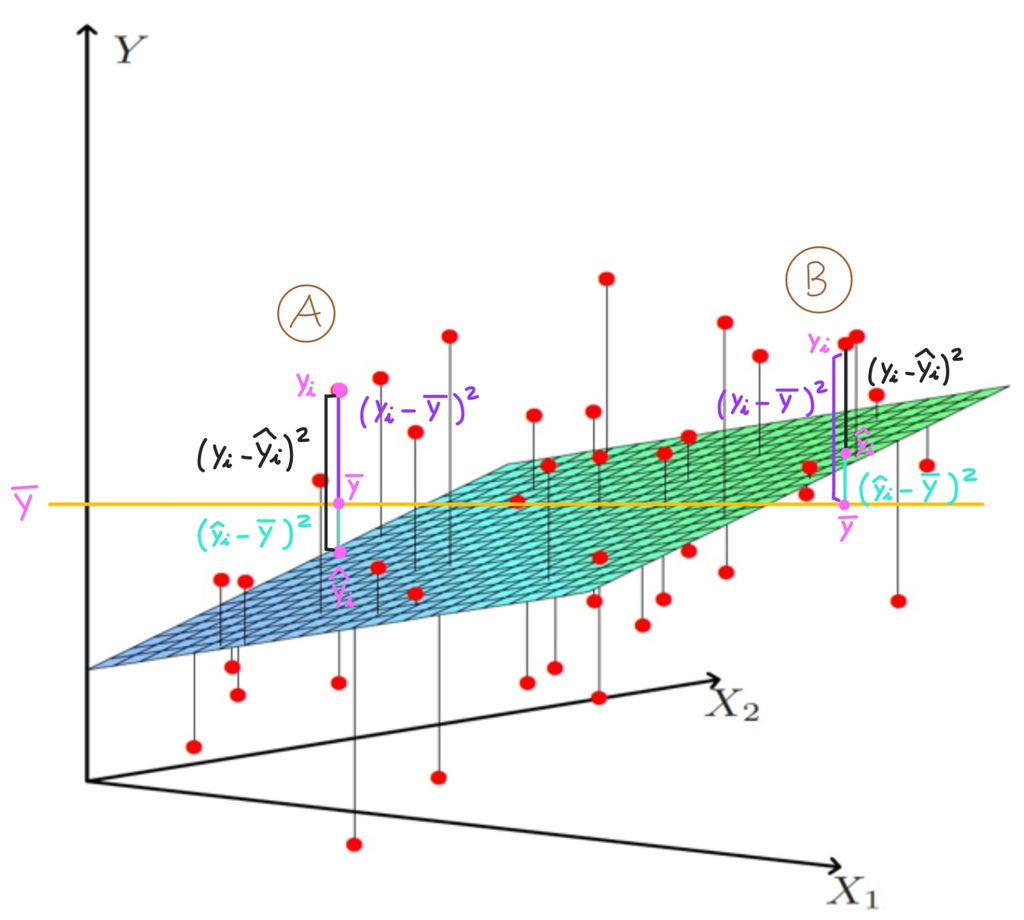

The image gives us relevant information:

Case A of the image is enough to prove that the following statement is false:

$$(y_i - \overline{y})^2 \hspace{0.1cm}= \hspace{0.1cm} (y_i - \widehat{y}_i)^2 + (\widehat{y}_i - \overline{ y})^2 \hspace{0.2cm} , \forall i=1,..,n$$

Although it is true that:

$$\sum_{i=1}^{n} (y_i - \overline{y})^2 \hspace{0.1cm}= \hspace{0.1cm} \sum_{i=1}^{n} (y_i - \widehat{y}_i)^2 + \sum_{i=1}^{n} (\widehat{y}_i - \overline{y})^2$$

Now we can define the test statistic as:

$$\begin{gather*}
F_{exp|H_0} \hspace{0.1cm}=\hspace{0.1cm} \dfrac{(TSS-RSS)/p}{RSS/(n-p-1)} \hspace{0.1cm}=\hspace{0.1cm} \dfrac{(RegSS)/p}{RSS/(n-p-1) } \sim F_{\hspace{0.05cm}p,\hspace{0.05cm} n-p-1}
\end{gather*}$$

Where: $\hspace{0.1cm} p \hspace{0.1cm}$ is the number of predictor variables $X_1,...,X_p$ of the model

**Observation:**

If $\hspace{0.1cm}RegSS\hspace{0.1cm}$ is large compared to $\hspace{0.1cm}RSS\hspace{0.1cm}$ then the variance of $\hspace{0.1cm}Y\hspace{0.1cm}$ explained by the model using $\hspace{0.1cm}X\hspace{0.1cm}$ will be large compared to the unexplained variance and $\hspace{0.1cm}F_{exp|H_0}\hspace{0.1cm}$ will be large

So large values of $\hspace{0.1cm}F_{exp|H_0}\hspace{0.1cm}$ indicate large values of $\hspace{0.1cm}RegSS\hspace{0.1cm}$ compared to $\hspace{0.1cm}RSS\hspace{0.1cm}$ , which is an indication that the model explains $\hspace{0.1cm}Y\hspace{0.1cm}$ well, so it would be reasonable to reject $\hspace{0.1cm}H_0\hspace{0.1cm}$ in favor of $\hspace{0.1cm}H_1\hspace{0.1cm}$, that is, reject that all the predictors are jointly insignificant in explaining the response, and accept that some of them are significant.

The decision rule that we will see next is based on this reasoning. The larger $\hspace{0.1cm}F_{exp|H_0}\hspace{0.1cm}$ is, the easier it is to reject $\hspace{0.1cm}H_0\hspace{0.1cm}$ in favor of $\hspace{0.1cm}H_1\hspace{0.1cm}$

$H_0\hspace{0.1cm}$ is rejected when $\hspace{0.1cm}F_{exp|H_0}\hspace{0.1cm}$ is large enough, that is, when $\hspace{0.1cm}RegSS\hspace{0.1cm}$ is large enough compared to $\hspace{0.1cm}RSS$

### 6.5.2 Decision Rule

- Based on statistic test:

$$\begin{gather*}
Reject \ H_0 \ \Leftrightarrow \ F_{exp|H_0} > F_{\alpha}^{\hspace{0.1cm}p,\hspace{0.05cm} n-p-1}
\end{gather*}$$

- Based on p-value:

$$\begin{gather*}
Reject \ H_0 \ \Leftrightarrow \ pvalue < \alpha
\end{gather*}$$

### 6.5.3 ANOVA test in `R`

The value of $\hspace{0.1cm} F_{exp|H_0}$ and also the p-value of the ANOVA test could be found in the output obtained with `summary(model_R_1)`

```r
%%R
summary(model_R)
```

```
Call:
lm(formula = price ~ size_in_m_2 + no_of_bedrooms + no_of_bathrooms +
    quality + latitude + longitude, data = data_R)

Residuals:
      Min        1Q    Median        3Q       Max
-13398393   -562302     68143    562733  15384235

Coefficients:
                  Estimate Std. Error t value Pr(>|t|)
(Intercept)     -6.207e+07  2.995e+07  -2.073   0.0383 *
size_in_m_2      3.566e+04  7.238e+02  49.271  < 2e-16 ***
no_of_bedrooms  -8.367e+05  8.282e+04 -10.102  < 2e-16 ***
no_of_bathrooms -5.712e+04  6.829e+04  -0.836   0.4030
quality1         1.400e+05  8.358e+04   1.675   0.0940 .
quality2         3.406e+05  1.551e+05   2.196   0.0282 *
quality3         2.788e+05  1.976e+05   1.410   0.1586
latitude         6.115e+06  7.809e+05   7.830 8.03e-15 ***
longitude       -1.677e+06  6.908e+05  -2.428   0.0153 *
---
Signif. codes:  0 '***' 0.001 '**' 0.01 '*' 0.05 '.' 0.1 ' ' 1

Residual standard error: 1605000 on 1896 degrees of freedom
Multiple R-squared:  0.6979,    Adjusted R-squared:  0.6966
F-statistic: 547.4 on 8 and 1896 DF,  p-value: < 2.2e-16
```

### 6.5.4 ANOVA test in `Python`

The value of $\hspace{0.1cm} F_{exp|H_0}$ and also the p-value of the ANOVA test could be found in the output obtained with `print(model_Python_1.summary())`

```python
print(model_Py_sm.summary())
```

```
                            OLS Regression Results
==============================================================================
Dep. Variable:                  price   R-squared:                       0.698
Model:                            OLS   Adj. R-squared:                  0.697
Method:                 Least Squares   F-statistic:                     547.4
Date:               sá., 22 oct. 2022   Prob (F-statistic):               0.00
Time:                        19:26:26   Log-Likelihood:                -29918.
No. Observations:                1905   AIC:                         5.985e+04
Df Residuals:                    1896   BIC:                         5.990e+04
Df Model:                           8
Covariance Type:            nonrobust
===================================================================================
                      coef    std err          t      P>|t|      [0.025      0.975]
-----------------------------------------------------------------------------------
intercept       -6.207e+07   2.99e+07     -2.073      0.038   -1.21e+08   -3.34e+06
size_in_m_2      3.566e+04    723.831     49.271      0.000    3.42e+04    3.71e+04
longitude       -1.677e+06   6.91e+05     -2.428      0.015   -3.03e+06   -3.22e+05
latitude         6.115e+06   7.81e+05      7.830      0.000    4.58e+06    7.65e+06
no_of_bedrooms  -8.367e+05   8.28e+04    -10.102      0.000   -9.99e+05   -6.74e+05
no_of_bathrooms -5.712e+04   6.83e+04     -0.836      0.403   -1.91e+05    7.68e+04
quality_1          1.4e+05   8.36e+04      1.675      0.094   -2.39e+04    3.04e+05
quality_2        3.406e+05   1.55e+05      2.196      0.028    3.63e+04    6.45e+05
quality_3        2.788e+05   1.98e+05      1.410      0.159   -1.09e+05    6.66e+05
==============================================================================
Omnibus:                      779.851   Durbin-Watson:                   1.716
Prob(Omnibus):                  0.000   Jarque-Bera (JB):            25742.187
Skew:                           1.273   Prob(JB):                         0.00
Kurtosis:                      20.828   Cond. No.                     1.34e+05
==============================================================================

Notes:
[1] Standard Errors assume that the covariance matrix of the errors is correctly specified.
[2] The condition number is large, 1.34e+05. This might indicate that there are
strong multicollinearity or other numerical problems.
```

We have got the following:

$$F_{exp|H_0} = 547.4 \hspace{0.5cm} \text{(F-statistic)}$$

$$pvalue \simeq 0 \hspace{0.5cm} \text{(Prob (F-statistic))}$$

So for any $\hspace{0.1cm} \alpha > 0 \hspace{0.1cm}$ we can reject $\hspace{0.1cm} H_0: \hspace{0.05cm} \beta_1=\dots =\beta_p=0 \hspace{0.15cm}$, so we can affirm the model is globally significant

## 6.6 Prediction Interval for response variable

We have that

$$\hat{y}_i \hspace{0.1cm}=\hspace{0.1cm} x_i^t \cdot \widehat{\beta} \hspace{0.1cm} \sim \hspace{0.1cm} N \left( \hspace{0.1cm} E[\hspace{0.1cm} \hat{y}_i \hspace{0.1cm}] \hspace{0.25cm},\hspace{0.25cm} \sigma^2 \cdot (1 + x_i^t \cdot (X^t \cdot X)^{-1} \cdot x_i ) \hspace{0.1cm} \right)$$

Using that we can get the following probability interval for $y_i$

$$PI(y_i)_{1-\alpha}\hspace{0.1cm} =\hspace{0.1cm} \left[\hspace{0.15cm} \hat{y}_i \hspace{0.15cm}\pm\hspace{0.15cm} t_{\alpha/2}^{n-p-1} \cdot \sqrt{ \widehat{\sigma}^2 \cdot \left( 1 + x_i^t \cdot (X^t \cdot X)^{-1} \cdot x_i \right) } \hspace{0.15cm} \right]$$

### 6.6.1 Prediction Interval for $\hspace{0.1cm} y_i$ in `Python`

```python
Y = data_Python[['price']]

X = data_Python[['size_in_m_2', 'longitude', 'latitude', 'no_of_bedrooms', 'no_of_bathrooms', 'quality']]

X = varcharProcessing(X, varchar_process = "dummy_dropfirst")
```

```python
Probability_Intervals_Response = pd.DataFrame({ 'y': 0 , 'y_predict': 0 ,  'Prob_Interval_lower': 0, 'Prob_Interval_upper': 0}, index= range(0,len(data_Python)))
```

```python
n=len(data_Python)

p=model_Py_smf.df_model

t = scipy.stats.t.ppf(0.95, n-p-1)

XtX_inv = np.linalg.inv(X.T @ X)

Probability_Intervals_Response.iloc[:, 0] = Y
Probability_Intervals_Response.iloc[:, 1] = predictions


for i in range(0, len(data_Python)-1):

    x_i = X.to_numpy()[i, ]
    x_i = np.array([x_i]) # necessary step to transpose a 1D array

    hat_y_i = predictions.to_numpy()[i, ]

    a = hat_y_i - np.sqrt( estimated_variance_error * ( 1 + x_i @ XtX_inv @ x_i.T ) )
    b = hat_y_i + np.sqrt( estimated_variance_error * ( 1 + x_i @ XtX_inv @ x_i.T ) )

    a = float(a)
    b = float(b)

    Probability_Intervals_Response.iloc[i, 2] = a
    Probability_Intervals_Response.iloc[i, 3] = b
```

```python
 Probability_Intervals_Response
```

|  | y | y_predict | Prob_Interval_lower | Prob_Interval_upper |
| --- | --- | --- | --- | --- |
| 0 | 2700000 | 1.781426e+06 | 1.756811e+05 | 3.387171e+06 |
| 1 | 2850000 | 2.551625e+06 | 9.459896e+05 | 4.157260e+06 |
| 2 | 1150000 | 2.522740e+06 | 9.137789e+05 | 4.131701e+06 |
| 3 | 2850000 | 4.222873e+06 | 2.615568e+06 | 5.830179e+06 |
| 4 | 1729200 | 7.851530e+05 | -8.220643e+05 | 2.392370e+06 |
| … | … | … | … | … |
| 1900 | 1500000 | 1.211313e+06 | -4.053818e+05 | 2.828007e+06 |
| 1901 | 1230000 | 8.171580e+05 | -7.881622e+05 | 2.422478e+06 |
| 1902 | 2900000 | 2.981084e+06 | 1.371368e+06 | 4.590800e+06 |
| 1903 | 675000 | 2.651215e+05 | -1.340281e+06 | 1.870524e+06 |
| 1904 | 760887 | 8.227585e+05 | 0.000000e+00 | 0.000000e+00 |

1905 rows × 4 columns

# 7 Goodness of Fit: $\hspace{0.1cm}$ Determination Coefficient

## 7.1 Determination Coefficient

The determination coefficient, also called R-square, is defined as:

$$\begin{gather*}
R^2 \hspace{0.1cm}=\hspace{0.1cm} \dfrac{RegSS}{TSS} \hspace{0.1cm}=\hspace{0.1cm} \dfrac{TSS-RSS}{TSS} \hspace{0.1cm}=\hspace{0.1cm} 1 - \dfrac{RSS}{TSS}
\end{gather*}$$

**Properties**

- $R^2$ is the proportion of total variance of the response variable $Y$ that is explained by the model using $X \\$
- $R^2 \in \left[ 0 , 1 \right]$

For this reason $\hspace{0.1cm}R^2\hspace{0.1cm}$ is used as a measure of how well the model fits the response variable .

**Interpretation**

The interpretation of $\hspace{0.1cm}R^2\hspace{0.1cm}$ is the following:

- If $\hspace{0.1cm}R^2\hspace{0.1cm}$ is close to $1$, indicates good fit of model to the response variable data $\\[0.5cm]$
- If $\hspace{0.1cm}R^2\hspace{0.1cm}$ is clode to $0$, indicates bad fit of model to the response variable data

### 7.1.1 Computing $R^2$ in `R`

The value of $\hspace{0.1cm} R^2$ could be found in the output obtained with `summary(model_R)`

```r
%%R

summary(model_R)$r.squared
```

```
[1] 0.6978674
```

### 7.1.2 Computing $R^2$ in `Python`

The value of $\hspace{0.1cm} R^2$ could be found in the output obtained with `print(model_Py_smf.summary())`

```python
model_Py_smf.rsquared
```

```
0.6978674339747218
```

We can compute $R^2$ with `sk-learn` as follows:

```python
Model_Py_sklearn.score(X, y)
```

```
0.6978674339747218
```

We have got the following:

$$R^2 = 0.698$$

## 7.2 Adjusted Determination Coefficient

$R^2$ has several problems.

$1.$ $\hspace{0.2cm} R^2$ always increase when increase the number of predictors, although they are not significative.

$2.\hspace{0.2cm}$ It´s possible estimate two models with the same prediction power but with different $\hspace{0.1cm}R^2$

For avoid the disadvantages of $\hspace{0.1cm}R^2\hspace{0.1cm}$ was created the adjusted $\hspace{0.1cm}R^2\hspace{0.1cm}$ , denoted as $\widehat{R^2}$, and defined as:

$$\begin{gather*}
\widehat{R}^2 = 1 - \dfrac{RSS/(n-p-1)}{TSS/(n-1)} = 1 - \left( 1- R^2 \right) \cdot \dfrac{n-1}{n-p}
\end{gather*}$$

This metric doesn’t grow when including irrelevant predictors, because if $\hspace{0.1cm} RSS\hspace{0.1cm}$ is small because of $\hspace{0.1cm}p\hspace{0.1cm}$ is large, then $\hspace{0.1cm}1/(n-p-1)\hspace{0.1cm}$ will be large compensating the $\hspace{0.1cm}RSS\hspace{0.1cm}$ value

### 7.2.1 Computing $\widehat{R}^2$ in `R`

The value of $\hspace{0.1cm} \widehat{R^2}$ could be found in the output obtained with `summary(model_R)`

```r
%%R

summary(model_R)$adj.r.squared
```

```
[1] 0.6965926
```

### 7.2.2 Computing $\widehat{R}^2$ in `Python`

The value of $\hspace{0.1cm} \widehat{R^2}$ could be found in the output obtained with `print(model_Py_smf.summary())`

```python
model_Py_smf.rsquared_adj
```

```
0.6965926130210287
```

We have got the following:

$$\widehat{R^2} = 0.697$$

# 8 Model Problems

## 8.1 Multicollinearity

Multicollinearity problem happens when some of the predictors are lineary dependients.

**Why multicollinearity is a problem ?**

1. In the worst case it makes the estimation of the model impossible.
2. At best, it makes the beta estimators have a lot of variance, which makes model predictions and inference very imprecise. And it also makes the predictors that are relevant turn out to be non-significant following the significance test.

### 8.1.1 Types of multicollinearity

#### 8.1.1.1 Perfect Multicollinearity

At least one of the predictors is a linear combination of the rest, so $\hspace{0.1cm}Rg(X) < p+1 \hspace{0.1cm}$ (not full range)

By the null rank theorem, $\hspace{0.1cm}R(X^t \cdot X) < p+1\hspace{0.1cm}$ , therefore $\hspace{0.1cm}X^t \cdot X\hspace{0.1cm}$ hasn’t full range, so there is no $\hspace{0.1cm}(X^t \cdot X)^{-1}\hspace{0.1cm}$ , so it cannot be estimate $\hspace{0.1cm}\beta\hspace{0.1cm}$ with the ordinary least squares method .

#### 8.1.1.2 High Multicollinearity

There are predictors with high linear correlation between them.

In this case is still possible estimate $\hspace{0.1cm}\beta\hspace{0.1cm}$ because the multicolinearity isn´t perfect, but the variance of the $\hspace{0.1cm}\beta_j\hspace{0.1cm}$ estimators, $\hspace{0.1cm}Var(\widehat{\beta}_j)\hspace{0.1cm}$, will be too high, therefore the model will be very imprecise, so the results will not be good.

### 8.1.2 Identification of multicollinearity

Identification of multicollinearity is carry out by several ways:

If the linear regression model has only **quantitative** predictors:

1. $\hspace{0.2cm}$ With the correlation matrix of the predictors $\hspace{0.05cm} R$
2. $\hspace{0.2cm}$ With $\hspace{0.1cm}VIF\hspace{0.1cm}$ (variance increase factor )
3. $\hspace{0.2cm}$ With condition number of $\hspace{0.05cm} R$

If the linear model has **quantitative** and **categorical** predictors:

1. $\hspace{0.2cm}$ With $\hspace{0.1cm}GVIF\hspace{0.1cm}$ (generalize variance increase factor)

#### 8.1.2.1 Identification of multicollinearity with $R$

The Pearson correlation matrix of a given data matrix $X=[X_1 ,..., X_p]$ is defined as:

$$R= \begin{pmatrix}
r_{11} & r_{12}&...&r_{1p}\\
r_{21} & r_{22}&...&r_{2p}\\
&...&\\
r_{p1}& r_{p2}&...&r_{pp}
\end{pmatrix} = [r_{ij} ]\hspace{0.05cm}_{i,j=1,..,p}$$

Where: $\hspace{0.2cm} r_{i j} \hspace{0.1cm}$ is the Pearson linear correlation between $X_i$ and $X_j$

**Criteria : Identification of multicollinearity with $R$**

If we have the following estimated linear regression model $\hspace{0.2cm} Y=X\cdot \widehat{\beta} \hspace{0.2cm}$ where $\hspace{0.2cm}X=(1, X_1, ..., X_p)\hspace{0.2cm}$ are all **quantitative** predictors.

We compute the Pearson linear correlation matrix of the predictors $\hspace{0.2cm} [ X_1 ,..., X_p] \hspace{0.2cm} \Rightarrow \hspace{0.2cm} R = [r_{ij} ]\hspace{0.05cm}_{i,j=1,..,p}$

- If there is any **high** $\hspace{0.2cm} r_{ij}\hspace{0.2cm} (\hspace{0.1cm} > 0.75 \hspace{0.1cm})$ $\hspace{0.2cm} \Rightarrow\hspace{0.2cm}$ possible multicollinearity problem

##### 8.1.2.1.1 Identification of multicollinearity with $R$ in `R`

We will suposse our linear regression model only has **quatitative** predictors.

We need to compute the Pearson correlation matrix for these quantitative predictors.

```r
%%R

R <- cor(data_R %>% select(-price, -quality))
R
```

```
                size_in_m_2   longitude  latitude no_of_bedrooms
size_in_m_2      1.00000000 -0.06665722 0.1375185     0.77511298
longitude       -0.06665722  1.00000000 0.6058747    -0.04566789
latitude         0.13751849  0.60587468 1.0000000     0.12416175
no_of_bedrooms   0.77511298 -0.04566789 0.1241617     1.00000000
no_of_bathrooms  0.72539720 -0.02499958 0.1411599     0.85438384
                no_of_bathrooms
size_in_m_2          0.72539720
longitude           -0.02499958
latitude             0.14115992
no_of_bedrooms       0.85438384
no_of_bathrooms      1.00000000
```

Now we will compute a heatmap with the correlation matrix:

```r
%%R

library(GGally)

ggcorr(data_R %>% select(-price, -quality), label=TRUE, digits=3)
```

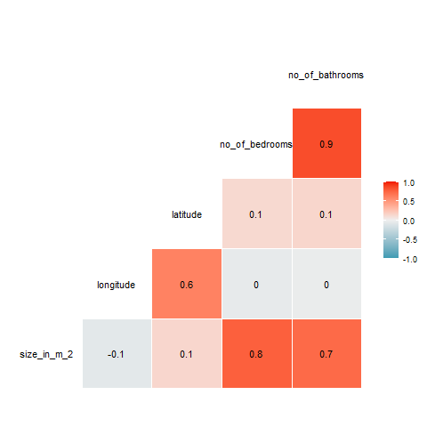

##### 8.1.2.1.2 Identification of multicollinearity with $R$ in `Python`

```python
X = data_Python.loc[: , ['size_in_m_2', 'longitude', 'latitude', 'no_of_bedrooms', 'no_of_bathrooms']]
```

```python
R = X.corr()

R
```

|  | size_in_m_2 | longitude | latitude | no_of_bedrooms | no_of_bathrooms |
| --- | --- | --- | --- | --- | --- |
| size_in_m_2 | 1.000000 | -0.066657 | 0.137518 | 0.775113 | 0.725397 |
| longitude | -0.066657 | 1.000000 | 0.605875 | -0.045668 | -0.025000 |
| latitude | 0.137518 | 0.605875 | 1.000000 | 0.124162 | 0.141160 |
| no_of_bedrooms | 0.775113 | -0.045668 | 0.124162 | 1.000000 | 0.854384 |
| no_of_bathrooms | 0.725397 | -0.025000 | 0.141160 | 0.854384 | 1.000000 |

```python
# pip install seaborn
```

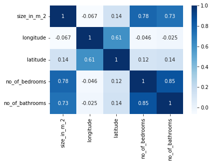

```python
import seaborn as sb

corr = R

sb.heatmap(corr, cmap="Blues", annot=True)
```

So following this criteria the linear regression model **price ~ size_in_m_2 + longitude + latitude + no_of_bedrooms + no_of_bathrooms** could has multicollinearity problems.

### 8.1.3 Identification of multicollinearity with $VIF$

If we have the following estimated linear regression model $\hspace{0.2cm} Y=X\cdot \widehat{\beta} \hspace{0.2cm}$ where $\hspace{0.2cm}X=(1, X_1, ..., X_p)\hspace{0.2cm}$ are all **quantitative** predictors.

We compute the **inverse** of the Pearson correlation matrix of the predictors $\hspace{0.1cm} [ X_1 ,..., X_p] \hspace{0.2cm} \Rightarrow \hspace{0.2cm} R\hspace{0.07cm}^{-1}$

The variance increase factor $\hspace{0.1cm}\left(VIF\right)\hspace{0.1cm}$ of the quantitative predictor $\hspace{0.1cm}X_j\hspace{0.1cm}$ is:

$$VIF(X_j) \hspace{0.05cm}=\hspace{0.05cm} Diag(R\hspace{0.07cm}^{-1})[\hspace{0.1cm} j \hspace{0.1cm}] \hspace{0.05cm}=\hspace{0.05cm} j \text{ element of} \hspace{0.1cm} Diag(R\hspace{0.07cm}^{-1})$$

And also it´s fullfield that:

$$VIF(X_j) = \dfrac{1}{1- R^2_{X_j}}$$

Where:

$R^2_{X_j}\hspace{0.1cm}$ is the determination coefficient $\hspace{0.1cm} (R^2)\hspace{0.1cm}$ of the linear regression model $\hspace{0.1cm} X_i = \beta_0 + \beta_1 \cdot X_1 +...+ \beta_{j-1}\cdot X_{j-1} + \beta_{i+1}\cdot X_{i+1} + ... + \beta_p \cdot X_p + \varepsilon$

So, $\hspace{0.07cm} R^2_{X_i} \hspace{0.07cm}$ is the proportion of variability of the predictor $\hspace{0.07cm}X_j\hspace{0.07cm}$ explained by the rest $\hspace{0.07cm}X_1,..,X_{j-1},X_{j+1},..,X_p$

**Criteria: Identification of multicollinearity with $VIF$**

- If $\hspace{0.2cm}VIF(X_j) > 10$ $\hspace{0.25cm}\left( R^2_{X_j} > 0.90 \right)$ $\hspace{0.25cm}\Rightarrow\hspace{0.25cm}$ **High** multicollinearity $\\[0.5cm]$
- If $\hspace{0.2cm}VIF(X_j) \in [4, 10]$ $\hspace{0.25cm}\left(R^2_{X_j} \in [0.75 , 0.90]\right)$ $\hspace{0.25cm}\Rightarrow\hspace{0.25cm}$ **Medium** multicollinearity $\\[0.5cm]$
- If $\hspace{0.2cm}VIF(X_j) < 4$ $\hspace{0.15cm}\left(R^2_{X_j} < 0.75 \right)$ $\hspace{0.25cm}\Rightarrow\hspace{0.25cm}$ **Low** multicollinearity

#### 8.1.3.1 Identification of multicollinearity with $VIF$ in `R`

```r
%%R

R_inverse <- solve(R)

diag(R_inverse)
```

```
    size_in_m_2       longitude        latitude  no_of_bedrooms no_of_bathrooms
       2.642728        1.639554        1.667913        4.565980        3.857961
```

```r
%%R

library(car)
library(carData)

vif(lm(price ~ size_in_m_2  + longitude + latitude + no_of_bedrooms + no_of_bathrooms , data=data_R))
```

```
    size_in_m_2       longitude        latitude  no_of_bedrooms no_of_bathrooms
       2.642728        1.639554        1.667913        4.565980        3.85796
```

#### 8.1.3.2 Identification of multicollinearity with $VIF$ in `Python`

```python
X = data_Python.loc[: , ['size_in_m_2', 'longitude', 'latitude', 'no_of_bedrooms', 'no_of_bathrooms']]

R = X.corr()
```

```python
R_inv_diag = np.diagonal( np.linalg.inv( R ) )
```

```python
predictors_names = X.columns
```

```python
VIF_Python = pd.DataFrame({'predictor': predictors_names , 'VIF': R_inv_diag })
VIF_Python = VIF_Python.set_index('predictor')
VIF_Python
```

| predictor | VIF |
| --- | --- |
| size_in_m_2 | 2.642728 |
| longitude | 1.639554 |
| latitude | 1.667913 |
| no_of_bedrooms | 4.565980 |
| no_of_bathrooms | 3.857961 |

There is a quantitative predictor with $\hspace{0.1cm} VIF > 4 \hspace{0.1cm}$ , but none with $\hspace{0.1cm} VIF > 10 \hspace{0.1cm}$ , so following this criteria the linear regression model $\hspace{0.1cm}$ **price ~ size_in_m_2 + longitude + latitude + no_of_bedrooms + no_of_bathrooms** $\hspace{0.1cm}$ has **medium** multicollinearity .

### 8.1.4 Identification of multicollinearity with Condition Number of $\hspace{0.05cm} R$

If we have the following estimated linear regression model $\hspace{0.2cm} Y=X\cdot \widehat{\beta} \hspace{0.2cm}$ where $\hspace{0.2cm}X=(1, X_1, ..., X_p)\hspace{0.2cm}$ are all **quantitative** predictors.

We compute the Pearson linear correlation matrix of the predictors $\hspace{0.2cm} [ X_1 ,..., X_p] \hspace{0.2cm} \Rightarrow \hspace{0.2cm} R = [r_{ij} ]\hspace{0.05cm}_{i,j=1,..,p}$

The **condition number** of $R$ is defined as:

$$cond(R) = \sqrt{\dfrac{max\lbrace eigenvalues(R)\rbrace}{min\lbrace eigenvalues(R)\rbrace}}$$

**Criteria : Identification of multicollinearity with Condition Number of $\hspace{0.05cm} R$**

- If $\hspace{0.1cm} cond(R) > 30$ $\hspace{0.1cm} \Rightarrow\hspace{0.1cm}$ **High** multicollinearity $\\[0.5cm]$
- If $\hspace{0.1cm}cond(R) \in (10 , 30)$ $\hspace{0.1cm} \Rightarrow\hspace{0.1cm}$ **Medium** multicollinearity $\\[0.5cm]$
- If $\hspace{0.1cm}cond(R) < 10$ $\hspace{0.1cm} \Rightarrow\hspace{0.1cm}$ **Low** multicollinearity $\\[0.5cm]$

#### 8.1.4.1 Identification of multicollinearity with condition number of $\hspace{0.05cm} R$ in `R`

```r
%%R

cond_R = sqrt(max(eigen(R)$values)/min(eigen(R)$values))
cond_R
```

```
[1] 4.325045
```

#### 8.1.4.2 Identification of multicollinearity with condition number of $\hspace{0.05cm} R$ in `Python`

```python
X = data_Python.loc[: , ['size_in_m_2', 'longitude', 'latitude', 'no_of_bedrooms', 'no_of_bathrooms']]

R = X.corr()
```

```python
from numpy import linalg as LA

eigenvalues , eigenvectors = LA.eig(R)
```

```python
cond_R = math.sqrt(max(eigenvalues)/min(eigenvalues))
cond_R
```

```
4.325045221905223
```

We have get $\hspace{0.1cm} cond(R) = 4.33 < 10 \hspace{0.1cm}$ , so following this criterion, the linear regression model $\hspace{0.1cm}$ **price ~ size_in_m_2 + longitude + latitude + no_of_bedrooms + no_of_bathrooms** $\hspace{0.1cm}$ has **low** multicollinearity

### 8.1.5 Identification of multicollinearity with $GVIF$

$VIF\hspace{0.2cm}$ is only a good multicollinearity measure when **all** the **predictors** of the model are **quantitative**.

$GVIF\hspace{0.2cm}$ is the measure proposed by Fox and Monette (1992) to deal with linear regression models that have **categorical predictors**.

Suppose we have the following estimated linear regression model $\hspace{0.2cm} Y=X\cdot \widehat{\beta} \hspace{0.2cm}$ where $\hspace{0.2cm}X=(1, X_1, ..., X_p)\hspace{0.2cm}$ are some **quantitative** and others **categorical** predictors.

If $X_j$ is a **quantitative** predictor

We have to consider the following matrix:

- $\hspace{0.2cm}\mathcal{X}_1 = [\hspace{0.1cm} X_j \hspace{0.1cm}]\\[0.45cm]$
- $\hspace{0.2cm}\mathcal{X}_2 = [\hspace{0.1cm} X_1 , .. , X_{j-1}, X_{j+1},.., X_p \hspace{0.1cm}]\\[0.45cm]$
- $\hspace{0.2cm}\mathcal{X}_3 = [\hspace{0.1cm} X_1,..,X_j,.., X_p \hspace{0.1cm}]$

And the following Pearson correlation matrix:

- $\hspace{0.2cm}R_1$ is the Pearson correlation matrix of $\hspace{0.2cm}\mathcal{X}_1 \\[0.45cm]$
- $\hspace{0.2cm}R_2$ is the Pearson correlation matrix of $\hspace{0.2cm}\mathcal{X}_2\\[0.45cm]$
- $\hspace{0.2cm}R_3$ is the Pearson correlation matrix of $\hspace{0.2cm}\mathcal{X}_3$

Then, $\hspace{0.1cm} GVIF \hspace{0.1cm}$ of $\hspace{0.1cm} X_j \hspace{0.1cm}$ is defined as:

$$GVIF(X_j) = det(R_1) \cdot \dfrac{det(R_2)}{det(R_3)}$$

If $X_j$ is a **categorical** predictor with $r$ categories, $\hspace{0.2cm} Range(X_j) = \lbrace 0,1,..., r-1 \rbrace \hspace{0.2cm}$ , that enter in the model with the dummy variables $\hspace{0.2cm} X_{j1},X_{j2},...,X_{j(r-1)}$

We have to consider the following matrix:

- $\mathcal{X}_1 = [\hspace{0.1cm} X_{j1},X_{j2},..,X_{j(r-1)} \hspace{0.1cm}]\\[0.45cm]$
- $\mathcal{X}_2 = [\hspace{0.1cm} X_1 , .. , X_{j-1}, X_{j+1},.., X_p \hspace{0.1cm}]\\[0.45cm]$
- $\mathcal{X}_3 = [\hspace{0.1cm} X_1,..,X_{j-1},X_{j1},X_{j2},..,X_{j(r-1)}, X_{j+1},.., X_p \hspace{0.1cm}]$

And the following Pearson correlation matrix:

- $R_1$ is the Pearson correlation matrix of $\mathcal{X}_1\\[0.45cm]$
- $R_2$ is the Pearson correlation matrix of $\mathcal{X}_2\\[0.45cm]$
- $R_3$ is the Pearson correlation matrix of $\mathcal{X}_3$

Then, $\hspace{0.05cm} GVIF \hspace{0.05cm}$ of $\hspace{0.05cm} X_j \hspace{0.05cm}$ is defined as:

$$GVIF(X_j) = det(R_1) \cdot \dfrac{det(R_2)}{det(R_3)}$$

**Criteria: Identification of multicollinearity with $GVIF$**

In this criteria the key quantity is $\hspace{0.2cm} GVIF(X_j)^{1/2 df}$

Where: $\hspace{0.2cm}df\hspace{0.2cm}$ is the number of parameters that enter in the linear regression model when $\hspace{0.2cm} X_j\hspace{0.2cm}$ is added as predictor

- If $\hspace{0.2cm}X_j\hspace{0.2cm}$ is a **quantitative** predictor $\hspace{0.2cm} ( \Rightarrow df=1)$ :
  - If $\hspace{0.2cm} GVIF(X_j)^{1/2} > \sqrt{10} = 3.16$ $\hspace{0.2cm}\Rightarrow\hspace{0.2cm}$ **High** multicollinearity $\\[0.45cm]$
  - If $\hspace{0.2cm} GVIF(X_j)^{1/2} \in [\sqrt{4}, \sqrt{10}]= [2 \hspace{0.1cm},\hspace{0.1cm} 3.16]$ $\hspace{0.2cm} \Rightarrow\hspace{0.2cm}$ **Medium** multicollinearity $\\[0.45cm]$
  - If $\hspace{0.2cm} GVIF(X_j)^{1/2} < \sqrt{4} = 2$ $\hspace{0.2cm}\Rightarrow\hspace{0.2cm}$ **Low** multicollinearity
- If $\hspace{0.2cm}X_j$ is a **categorical** predictor with $2$ categories $\hspace{0.2cm} ( \Rightarrow df=2-1=1)$
  - If $\hspace{0.2cm} GVIF(X_j)^{1/2} > 10^{1/2} = 3.16$ $\hspace{0.2cm}\Rightarrow\hspace{0.2cm}$ **High** multicollinearity $\\[0.45cm]$
  - If $\hspace{0.2cm} GVIF(X_j)^{1/2} \in [4^{1/2}, 10^{1/2}] = [2 \hspace{0.1cm} , \hspace{0.1cm} 3.16]$ $\hspace{0.2cm} \Rightarrow\hspace{0.2cm}$ **Medium** multicollinearity $\\[0.45cm]$
  - If $\hspace{0.2cm} GVIF(X_j)^{1/2} < 4^{1/2} = 2$ $\hspace{0.2cm}\Rightarrow\hspace{0.2cm}$ **Low** multicollinearity
- If $X_j$ is a **categorical** predictor with $3$ categories $\hspace{0.2cm} ( \Rightarrow df=3-1=2 )$ :
  - If $\hspace{0.2cm} GVIF(X_j)^{1/4} > 10^{1/4} = 1.78$ $\hspace{0.2cm}\Rightarrow\hspace{0.2cm}$ **High** multicollinearity $\\[0.45cm]$
  - If $\hspace{0.2 cm} GVIF(X_j)^{1/4} \in [4^{1/4}, 10^{1/4}] = [1.41 \hspace{0.1cm} , \hspace{0.1cm} 1.78]$ $\hspace{0.2cm} \Rightarrow\hspace{0.2cm}$ **Medium** multicollinearity $\\[0.45cm]$
  - If $\hspace{0.2cm} GVIF(X_j)^{1/4} < 4^{1/4} = 1.41$ $\hspace{0.2cm}\Rightarrow\hspace{0.2cm}$ **Low** multicollinearity
- If $\hspace{0.2cm}X_j\hspace{0.2cm}$ is a **categorical** predictor with $4$ categories $(\hspace{0.2cm} \Rightarrow df=4-1=3 )$
  - If $\hspace{0.2cm} GVIF(X_j)^{1/6} > 10^{1/6} = 1.47$ $\hspace{0.2cm}\Rightarrow\hspace{0.2cm}$ **High** multicollinearity $\\[0.45cm]$
  - If $\hspace{0.2cm} GVIF(X_j)^{1/6} \in [4^{1/6}, 10^{1/6}] = [1.26 \hspace{0.1cm} , \hspace{0.1cm} 1.47]$ $\hspace{0.2cm} \Rightarrow\hspace{0.2cm}$ **Medium** multicollinearity $\\[0.45cm]$
  - If $\hspace{0.2cm} GVIF(X_j)^{1/6} < 4^{1/6} = 1.26$ $\hspace{0.2cm}\Rightarrow\hspace{0.2cm}$ **Low** multicollinearity
- If $\hspace{0.2cm}X_j\hspace{0.2cm}$ is a **categorical** predictor with $r$ categories $(\hspace{0.2cm} \Rightarrow df=r-1 )$ :
  - If $\hspace{0.2cm} GVIF(X_j)^{1/(2(r-1))} > 10^{1/(2(r-1))}$ $\hspace{0.2cm}\Rightarrow\hspace{0.2cm}$ **High** multicollinearity $\\[0.45cm]$
  - If $\hspace{0.2cm} GVIF(X_j)^{1/(2(r-1))} \in [4^{1/(2(r-1))}, 10^{1/(2(r-1))}]$ $\hspace{0.2cm} \Rightarrow\hspace{0.2cm}$ **Medium** multicollinearity $\\[0.45cm]$
  - If $\hspace{0.2cm} GVIF(X_j)^{1/(2(r-1))} < 4^{1/(2(r-1))}$ $\hspace{0.2cm}\Rightarrow\hspace{0.2cm}$ **Low** multicollinearity

#### 8.1.5.1 Identification of multicollinearity with $GVIF$ in `R`

```r
%%R

library(car)
library(carData)

vif(lm(price ~ size_in_m_2  + longitude + latitude + no_of_bedrooms + no_of_bathrooms + quality , data=data_R))
```

```
                    GVIF Df GVIF^(1/(2*Df))
size_in_m_2     2.657446  1        1.630168
longitude       1.670001  1        1.292285
latitude        1.769812  1        1.330343
no_of_bedrooms  4.572529  1        2.138347
no_of_bathrooms 3.897807  1        1.974286
quality         1.080988  3        1.013064
```

#### 8.1.5.2 Identification of multicollinearity with $GVIF$ in `Python`

$GVIF$ for the **categorical** predictor $quality$

```python
X = data_Python.loc[: , ['size_in_m_2', 'longitude', 'latitude', 'no_of_bedrooms', 'no_of_bathrooms', 'quality']]
```

```python
X1 = varcharProcessing(X).loc[:, ['quality_1', 'quality_2', 'quality_3']]
X2 = X.drop({'quality'}, axis=1)
X3 = varcharProcessing(X).drop({'intercept'}, axis=1)

GVIF_quality = np.linalg.det(X1.corr()) * np.linalg.det(X2.corr()) / np.linalg.det(X3.corr())

df_quality = X1.shape[1]

GVIF_quality_scaled = GVIF_quality**(1/(2*df_quality))
```

$GVIF$ for the rest of **quantitative** predictors

```python
X = data_Python.loc[: , ['size_in_m_2', 'longitude', 'latitude', 'no_of_bedrooms', 'no_of_bathrooms', 'quality']]
```

```python
X1 = X[['size_in_m_2']]
X2 = X.drop(['size_in_m_2'], axis=1)
X3 = X

GVIF_size_in_m_2 = np.linalg.det(X1.corr()) * np.linalg.det(X2.corr()) / np.linalg.det( X3.corr() )

df_size_in_m_2 = X1.shape[1]

GVIF_size_in_m_2_scaled = GVIF_size_in_m_2**(1/(2*df_size_in_m_2))
```

```python
X1 = X[['longitude']]
X2 = X.drop(['longitude'], axis=1)
X3 = X


GVIF_longitude = np.linalg.det(X1.corr()) * np.linalg.det(X2.corr()) / np.linalg.det( X3.corr() )

df_longitude = X1.shape[1]

GVIF_longitude_scaled = GVIF_longitude**(1/(2*df_longitude))
```

```python
X1 = X[['latitude']]
X2 = X.drop(['latitude'], axis=1)
X3 = X

GVIF_latitude = np.linalg.det(X1.corr()) * np.linalg.det(X2.corr()) / np.linalg.det(  X3.corr() )

df_latitude = X1.shape[1]

GVIF_latitude_scaled = GVIF_latitude**(1/(2*df_latitude))
```

```python
X1 = X[['no_of_bedrooms']]
X2 = X.drop(['no_of_bedrooms'], axis=1)
X3 = X

GVIF_no_of_bedrooms = np.linalg.det(X1.corr()) * np.linalg.det(X2.corr()) / np.linalg.det( X3.corr() )

df_no_of_bedrooms = X1.shape[1]

GVIF_no_of_bedrooms_scaled = GVIF_no_of_bedrooms**(1/(2*df_no_of_bedrooms))
```

```python
X1 = X[['no_of_bathrooms']]
X2 = X.drop(['no_of_bathrooms'], axis=1)
X3 = X

GVIF_no_of_bathrooms = np.linalg.det(X1.corr()) * np.linalg.det(X2.corr()) / np.linalg.det( X3.corr())

df_no_of_bathrooms = X1.shape[1]

GVIF_no_of_bathrooms_scaled = GVIF_no_of_bathrooms**(1/(2*df_no_of_bathrooms))
```

```python
a = X.columns

b = [GVIF_size_in_m_2, GVIF_longitude, GVIF_latitude, GVIF_no_of_bedrooms, GVIF_no_of_bathrooms, GVIF_quality]

c = [GVIF_size_in_m_2_scaled, GVIF_longitude_scaled, GVIF_latitude_scaled, GVIF_no_of_bedrooms_scaled, GVIF_no_of_bathrooms_scaled, GVIF_quality_scaled]

d = [df_size_in_m_2, df_longitude, df_latitude, df_no_of_bedrooms, df_no_of_bathrooms, df_quality]

GVIF_Python_df = pd.DataFrame({'predictor': a , 'GVIF': b , 'GVIF^(1/(2*df))': c , 'df': d})

GVIF_Python_df
```

|  | predictor | GVIF | GVIF^(1/(2*df)) | df |
| --- | --- | --- | --- | --- |
| 0 | size_in_m_2 | 2.642728 | 1.625647 | 1 |
| 1 | longitude | 1.639554 | 1.280451 | 1 |
| 2 | latitude | 1.667913 | 1.291477 | 1 |
| 3 | no_of_bedrooms | 4.565980 | 2.136815 | 1 |
| 4 | no_of_bathrooms | 3.857961 | 1.964169 | 1 |
| 5 | quality | 1.080988 | 1.013064 | 3 |

On the other hand the 4-ary categorical predictor **quality** has $\hspace{0.1cm} GVIF^{1/2df}\hspace{0.1cm} = 1.01 < 1.26$ $ $ **low** multicollinearity

So using the GVIF method, we can conclude that there is a **medium** multicollinearity between the predictors of the model $\hspace{0.1cm}$ **price ~ size_in_m_2 + longitude + latitude + no_of_bedrooms + no_of_bathrooms** $\hspace{0.1cm}$

## 8.2 Checking Error Assumptions

- $\hspace{0.2cm} \varepsilon_i \sim N(0,\sigma) \hspace{0.5cm} \forall \hspace{0.1cm} i=1,...,n \\[0.35cm]$
- $\hspace{0.2cm} corr(\varepsilon_i , \varepsilon_j)=0 \hspace{0.5cm} \forall \hspace{0.1cm} i\neq j =1,...,n$

### 8.2.1 Checking Error Constant Variance

It is not possible to check the assumption of constant variance just by examining the residuals alone, some will be large and some will be small, but this proves nothing. We need to check whether the variance in the residuals is related to some other quantity.

- The most useful diagnostic is a plot of $\hat{\varepsilon}$ vs $\hat{Y}$
- Interpretation of the graph $\hat{\varepsilon}$ vs $\hat{y}$:
  - If the dispersion of the points is uniform random $\Rightarrow$ There is no problem (evidence of constant variance of the error).
  - If we can see a cone shape at the points $\Rightarrow$ Problem (evidence of error not constant variance)

This plot can also provide evidence of nonlinearity between the response variable and the predictors:

- If we can see a non-linear shape at the points $\Rightarrow$ evidence of non-linearity between the response variable and the predictors

#### 8.2.1.1 Checking Error Constant Variance in `R`

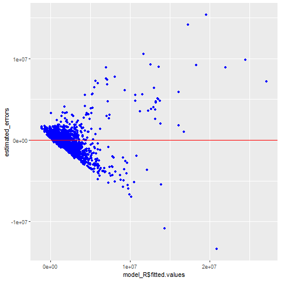

```r
%%R

ggplot() +
geom_point(mapping = aes(x=model_R$fitted.values , y = estimated_errors ), color="blue")+
geom_hline(yintercept =0 , color="red")
```

#### 8.2.1.2 Checking Error Constant Variance in `Python`

```python
from plotnine import ggplot, aes, geom_line, geom_point, geom_smooth, geom_histogram, geom_bar, geom_boxplot, scale_y_continuous, scale_x_continuous, scale_x_discrete, scale_y_discrete, labs, after_stat,  geom_vline, scale_color_manual, theme_gray, theme_xkcd, scale_color_identity, geom_hline, facet_wrap, scale_fill_discrete, scale_fill_manual,  scale_fill_hue, guides, guide_legend, geom_hline, stat_function
```

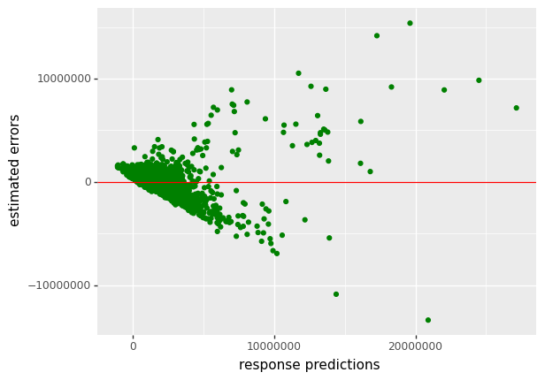

```python
(
ggplot()
+ geom_point(mapping = aes(x=predictions , y = df_predictions_Python['estimated_errors'] ), color="green")
+ geom_hline(yintercept =0 , color="red")
+ labs(x='response predictions' , y='estimated errors')
)
```

Since we can see a cone shape at the points, we cannot accept the constant error variance assumption $Var(\varepsilon)=\sigma^2$.

### 8.2.2 Checking Null Error Mean

We are going to use the typical t-test to verify this assumption.

First we compute the estimated errors mean to get first idea:

```python
df_predictions_Python['estimated_errors'].mean()
```

```
-1.5501118707531706e-07
```

#### 8.2.2.1 Checking Null Error Mean in `R`

```r
%%R

t.test(x=estimated_errors , mu=0)
```

```
    One Sample t-test

data:  estimated_errors
t = -5.1697e-12, df = 1904, p-value = 1
alternative hypothesis: true mean is not equal to 0
95 percent confidence interval:
 -71952.49  71952.49
sample estimates:
    mean of x
-1.896638e-07
```

#### 8.2.2.2 Checking Null Error Mean in `Python`

```python
# pip install --upgrade pingouin
```

```python
import pingouin as pg

pg.ttest(x= df_predictions_Python['estimated_errors'] , y=0)
```

|  | T | dof | alternative | p-val | CI95% | cohen-d | BF10 | power |
| --- | --- | --- | --- | --- | --- | --- | --- | --- |
| T-test | -4.225144e-12 | 1904 | two-sided | 1.0 | [-71952.49, 71952.49] | 9.680415e-14 | 0.026 | 0.05 |

For any significance level we can accept that the errors mean is zero (0)

### 8.2.3 Checking Error Normality

First we are going to check the error normality assumption using the **histogram method**

#### 8.2.3.1 Checking Error Normality in `R` with histogram method

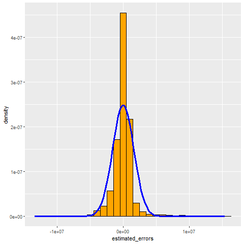

```r
%%R

ggplot(data = as.data.frame(estimated_errors) ,
 mapping = aes(x = estimated_errors)) +
 geom_histogram(aes(y =..density..), color="black", fill="orange",
 position = 'identity') +
 stat_function( fun = dnorm ,
 args = list(mean = mean(estimated_errors), sd = sd(estimated_errors)),
 lwd = 1.2,  col = 'blue'
 )
```

#### 8.2.3.2 Checking Error Normality in `Python` with histogram method

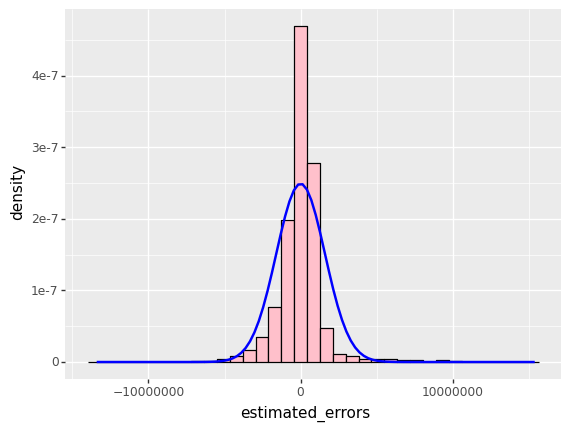

```python
import scipy.stats as stats
(
ggplot(data = df_predictions_Python ,
 mapping = aes(x = df_predictions_Python['estimated_errors']))
+ geom_histogram(aes(y = after_stat('density')), color="black", fill="pink", position = 'identity', bins=35)
+ stat_function( fun = stats.norm.pdf , args = dict( loc=mean(df_predictions_Python['estimated_errors']), scale=sd(df_predictions_Python['estimated_errors'])) , color='blue', size=1 )
)
```

Now we are going to check the error normality assumption using the Shapiro statistical test.

#### 8.2.3.3 Checking Error Normality in `R` with Shapiro test

```r
%%R

shapiro.test(estimated_errors)
```

```
    Shapiro-Wilk normality test

data:  estimated_errors
W = 0.79149, p-value < 2.2e-16
```

#### 8.2.3.4 Checking Error Normality in `Python` with Shapiro test

```python
shapiro_test = stats.shapiro(df_predictions_Python['estimated_errors'])
shapiro_test
```

```
ShapiroResult(statistic=0.7914911508560181, pvalue=4.203895392974451e-44)
```

For any significance level we have to reject the errors normality hypothesis.

### 8.2.4 Checking Null Error Correlation

We are going to check the null error correlation assumption through the **Durban-Watson test**.

**Hypothesis:**

$$H_0: \hspace{0.1cm} corr\left(\hat{\varepsilon}_{(1)},\hat{\varepsilon}_{(2)}\right) = 0$$

$$H_1: \hspace{0.1cm} corr\left(\hat{\varepsilon}_{(1)},\hat{\varepsilon}_{(2)}\right) \neq 0$$

Where:

$$\hat{\varepsilon}_{(1)} = (\hat{\varepsilon}_1 , \hat{\varepsilon}_2 ,..., \hat{\varepsilon}_{n-1})$$

$$\hat{\varepsilon}_{(2)} = (\hat{\varepsilon}_2 ,...,\hat{\varepsilon}_{n-1}, \hat{\varepsilon}_{n})$$

**Test Statistic :**

$$\begin{gather*}
DW = \dfrac{\sum_{i=2}^n (\hat{\varepsilon}_i - \hat{\varepsilon}_{i-1})^2 }{\sum_{i=2}^n \hat{\varepsilon}_{i}^2 } = \dfrac{sum\left( \hspace{0.1cm}( \hat{\varepsilon}_{(2)} - \hat{\varepsilon}_{(1)})^2 \hspace{0.1cm} \right)}{sum\left( \hspace{0.1cm} (\hat{\varepsilon}_{(2)})^2 \hspace{0.1cm} \right)}
\end{gather*}$$

The test statistic is approximately equal to $\hspace{0.1cm} 2\cdot (1-r) \hspace{0.1cm}$ where $r$ is the sample autocorrelation of the residuals. Thus, the test statistic will always be between $0$ and $4$ with the following interpretation:

A test statistic of $2$ indicates **no serial correlation**.

The closer the test statistics is to $0$, the more evidence of **positive serial correlation**.

The closer the test statistics is to $4$, the more evidence of **negative serial correlation**.

#### 8.2.4.1 Durban-Watson test in `R`

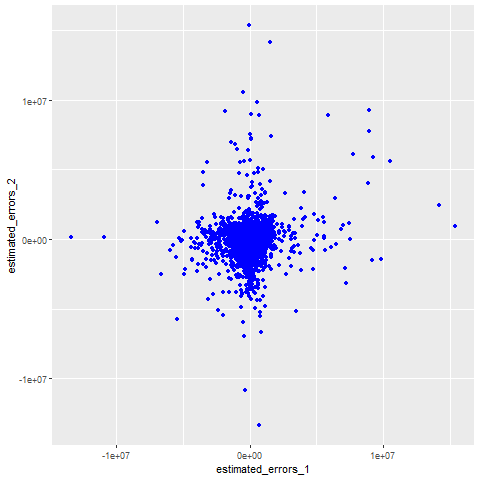

```r
%%R

estimated_errors_1 = estimated_errors[-1]
estimated_errors_2 = estimated_errors[-length(estimated_errors)]

ggplot() +
geom_point(mapping = aes(x=estimated_errors_1 , y = estimated_errors_2 ), color="blue")
```

```r
%%R
library(zoo)
library(lmtest)

dwtest(price ~ size_in_m_2  + longitude + latitude + no_of_bedrooms + no_of_bathrooms + quality , data=data_R, alternative = 'two.sided' )
```

```
    Durbin-Watson test

data:  price ~ size_in_m_2 + longitude + latitude + no_of_bedrooms +     no_of_bathrooms + quality
DW = 1.7158, p-value = 4.52e-10
alternative hypothesis: true autocorrelation is not 0
```

#### 8.2.4.2 Durban-Watson test in `Python`

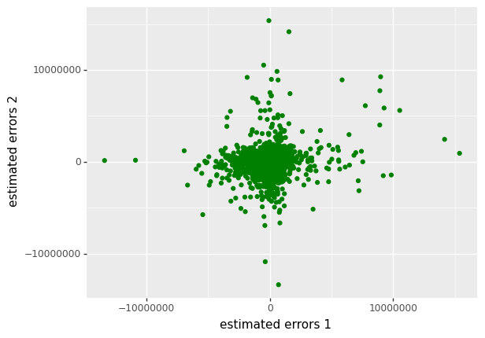

```python
train_errors_1 = pd.DataFrame({ 'train_errors_1': df_predictions_Python.iloc[range(1, len(df_predictions_Python)) , 2 ] } )
train_errors_2 = pd.DataFrame({ 'train_errors_1': df_predictions_Python.iloc[range(0, len(df_predictions_Python)-1) , 2 ] } )

train_errors_2['index']=range(1,len(train_errors_2)+1)
train_errors_2 = train_errors_2.set_index('index')

(
ggplot()
+ geom_point(mapping = aes(x=train_errors_1 , y = train_errors_2 ), color="green")
+ labs(x='estimated errors 1' , y='estimated errors 2')
)
```

```python
import statsmodels

statsmodels.stats.stattools.durbin_watson(df_predictions_Python['estimated_errors'], axis=0)
```

```
1.7158064595327671
```

Another alternative in Python that gives us the p-value:

```python
# pip install dwtest
```

More information about this Python package here https://github.com/JackywithaWhiteDog/dwtest

```python
from dwtest import dwtest
```

```python
statistic, pvalue = dwtest( 'price ~ size_in_m_2  + longitude + latitude + no_of_bedrooms + no_of_bathrooms'  , data_Python)
```

```python
statistic, pvalue
```

```
(1.720186802122348, 5.373510268400102e-10)
```

For any $\alpha$ we reject the null error correlation hypothesis.

## 8.3 Checking Linear Assumption

The linear regression model assumes that there is a **linear** relationship between the response and the predictors.

If the actual relationship is not linear, then all the conclusions we draw from the linear model are questionable.

**How to identify non-linearity?**

- Make a plot of the estimated errors (residuals) against the predictions of the response (all with the train data) $\hspace{0.2cm}\Rightarrow\hspace{0.2cm} \widehat{\varepsilon}\hspace{0.2cm} vs \hspace{0.2cm}\widehat{Y}$
  - It is the same plot as the one used to diagnose heteroscedasticity of the residuals (non-constant variance of the residuals).
  - If a non-linear relationship is observed in the graph, it indicates non-linearity between the predictors and the response.
- Non-linearity can also be detectedby plotting the response versus predictors (one-to-one) $\hspace{0.2cm}\Rightarrow\hspace{0.2cm} Y \hspace{0.2cm} vs \hspace{0.2cm} X_j$

**Solutions:**

A logarithmic transformation of the response variable could help. But the best option is to use a nonlinear (or nonparametric) regression method.

**Identification non-linearity with scatter plots: response vs predictors (one-to-one)**

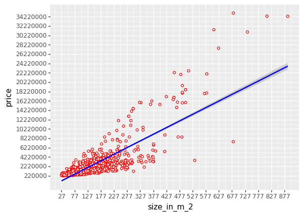

```python
(
ggplot(aes(x = 'size_in_m_2' , y = 'price') , data_Python)

 + geom_point(fill="white", color = 'red')
 + geom_smooth(method='lm', color = 'blue')
 + labs(x = "size_in_m_2", y = "price")
 + scale_x_continuous( breaks = range(int(data_Python['size_in_m_2'].min()) , int(data_Python['size_in_m_2'].max()) , 50) )
 + scale_y_continuous( breaks = range(int(data_Python['price'].min()) , int(data_Python['price'].max()) , 2000000) )
)
```

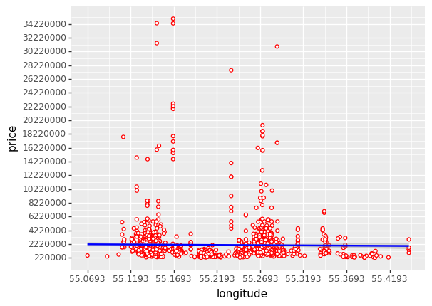

```python
(
ggplot(aes(x = 'longitude' , y = 'price') , data_Python)

 + geom_point(fill="white", color = 'red')
 + geom_smooth(method='lm', color = 'blue')
 + labs(x = "longitude", y = "price")
 + scale_x_continuous( breaks = np.arange (data_Python['longitude'].min() , data_Python['longitude'].max() , 0.05) )
 + scale_y_continuous( breaks = range(int(data_Python['price'].min()) , int(data_Python['price'].max()) , 2000000) )
)
```

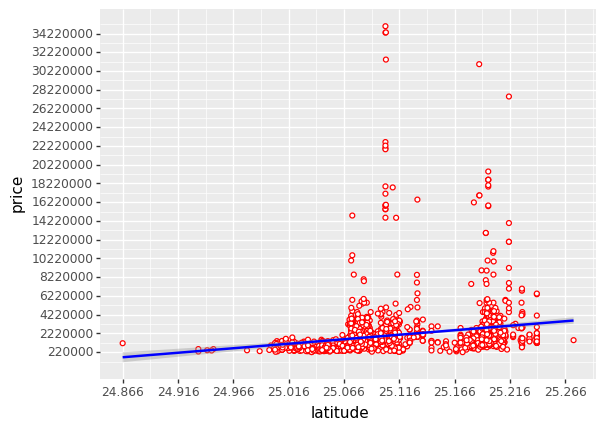

```python
(
ggplot(aes(x = 'latitude' , y = 'price') , data_Python)

 + geom_point(fill="white", color = 'red')
 + geom_smooth(method='lm', color = 'blue')
 + labs(x = "latitude", y = "price")
 + scale_x_continuous( breaks =  np.arange (data_Python['latitude'].min() , data_Python['latitude'].max() , 0.05)  )
 + scale_y_continuous( breaks = range(int(data_Python['price'].min()) , int(data_Python['price'].max()) , 2000000) )
)
```

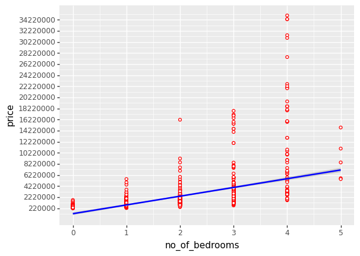

```python
(
ggplot(aes(x = 'no_of_bedrooms' , y = 'price') , data_Python)

 + geom_point(fill="white", color = 'red')
 + geom_smooth(method='lm', color = 'blue')
 + labs(x = "no_of_bedrooms", y = "price")
 + scale_x_continuous( breaks =  np.arange (data_Python['no_of_bedrooms'].min() , data_Python['no_of_bedrooms'].max()+1 , 1)  )
 + scale_y_continuous( breaks = range(int(data_Python['price'].min()) , int(data_Python['price'].max()) , 2000000) )
)
```

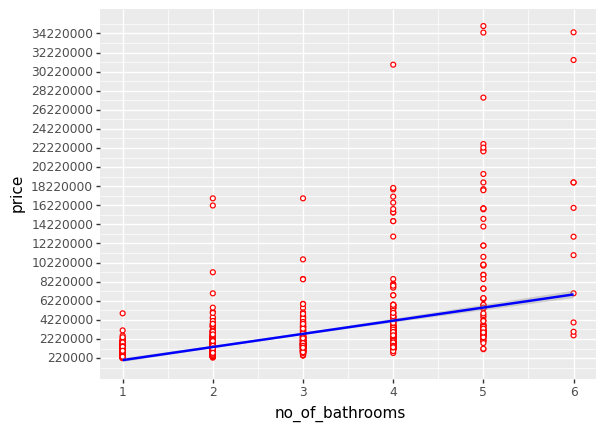

```python
(
ggplot(aes(x = 'no_of_bathrooms' , y = 'price') , data_Python)

 + geom_point(fill="white", color = 'red')
 + geom_smooth(method='lm', color = 'blue')
 + labs(x = "no_of_bathrooms", y = "price")
 + scale_x_continuous( breaks =  np.arange (data_Python['no_of_bathrooms'].min() , data_Python['no_of_bathrooms'].max()+1 , 1)  )
 + scale_y_continuous( breaks = range(int(data_Python['price'].min()) , int(data_Python['price'].max()) , 2000000) )
)
```

```python
data_Python['quality'] = data_Python['quality'].astype('int')
```

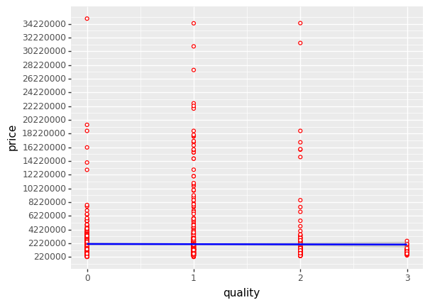

```python
(
ggplot(aes(x = 'quality' , y = 'price') , data_Python)

 + geom_point(fill="white", color = 'red')
 + geom_smooth(method='lm', color = 'blue')
 + labs(x = "quality", y = "price")
 + scale_x_continuous( breaks = np.arange (data_Python['quality'].min() , data_Python['quality'].max()+1 , 1) )
 + scale_y_continuous( breaks = range(int(data_Python['price'].min()) , int(data_Python['price'].max()) , 2000000) )
)
```

## 8.4 Finding Outliers

An outlier is a point that clearly deviates from the relationship between the response and the predictors.

Outliers can greatly affect the estimates of model parameters.

How to identify outliers?

A simple option is with the standardized residuals, given by:

$$\tilde{\varepsilon_i} = \dfrac{\hat{\varepsilon}_i}{\sqrt{\widehat{Var}(\hat{\varepsilon}_i)}} = \dfrac{\hat{\varepsilon}_i}{ \sqrt{ \widehat{\sigma}^2 \cdot (1-h_{ii})} }$$

Where:

$\hspace{0.1cm} h_{ii} \hspace{0.1cm}$ is the $i$-th element of the principal diagonal of $\hspace{0.1cm} H=X \cdot (X^t \cdot X)^{-1} \cdot X^t \hspace{0.1cm}$

Note that:

$$\widehat{Var}(\hat{\varepsilon}_i) \neq \widehat{Var}(\varepsilon_i)$$

Because $\varepsilon_i$ is a random variable such that $\hspace{0.1cm}\varepsilon_i \sim N (0\hspace{ 0.1cm},\hspace{0.1cm} \sigma^2) \hspace{0.1cm}$ (by initial hypothesis of the model)

And $\hspace{0.1cm} \hat{\varepsilon}_i = y_i - \hat{y}_i \hspace{0.1cm}$ is another random variable such that $\hspace{0.1cm} \hat{\varepsilon}_i \sim N(0\hspace{0.1cm},\hspace{0.1cm}\sigma^2 \cdot (1-h_{ii})) \hspace{0.1cm}$ (can be proof)

**Criteria: Outliers Identification**

**Observations** whose **studentized residuals** are **greater than 3** (in absolute value) will be considered outliers.

What to do with outliers:

If they are the result of an error in data collection, they can be deleted. If not, it shouldn’t, since it is part of the reality reflected by the sample, and is therefore relevant information.

### 8.4.1 Outliers Identification in `Python`

```python
H = np.dot(X @ np.linalg.inv( X.T @ X ) , X.T)

standardized_estimated_errors = estimated_errors / np.sqrt(estimated_variance_error*(1-np.diag(H)) )
```

```python
Outliers_df = pd.DataFrame({'standardized_estimated_errors > 3' : standardized_estimated_errors > 3})
```

```python
Outliers_df.head()
```

|  | standardized_estimated_errors > 3 |
| --- | --- |
| 0 | False |
| 1 | False |
| 2 | False |
| 3 | False |
| 4 | False |

```python
Outliers = Outliers_df.loc[ Outliers_df['standardized_estimated_errors > 3'] == True , : ].index
```

```python
Outliers
```

```
Int64Index([  60,  216,  235,  336,  343,  427,  456,  460,  461,  462, 463, 464,  465,  475,  476,  517,  576,  790,  836,  970,  989, 1189, 1259, 1487, 1515, 1690, 1697, 1869, 1885], dtype='int64')
```

# 9 Bibliography

Benitez Peña, S. (2021). *El modelo de regresión lineal múltiple* [Presentación de PowerPoint]. Aula Global UC3M.

Benitez Peña, S. (2021). *Inferencia en el modelo de regresión lineal múltiple* [Presentación de PowerPoint]. Aula Global UC3M.

Benitez Peña, S. (2021). *Diagnosis y validacion del modelo de regresión lineal múltiple* [Presentación de PowerPoint]. Aula Global UC3M.

Galeano, P. (2022). *Regresion Lineal Múltiple* [Presentación de PowerPoint]. Aula Global UC3M.

Fox, J. (2022). *Diagnosing Collinearity* [Presentación de PowerPoint]. McMaster University

Faraway, J (2015). *Linear Models with R* (second edition). CRC Press.